# JEPS version: analysis

Tables and figures for `jeps_paper.tex` / `jeps_appendix.tex`

Author

Felix Hartmann, Ferdinand Geissler, Macartan Humphreys, Heike Klüver, Johannes Giesecke

This file produces the JEPS draft exhibits.

**Plot layout (order / prior / party).** Columns in **appendix** grids are the five outcomes, left to right: Belief, Behave, Credible, Competent, Correct, one continuous `facet_grid`. Belief-side outcomes come first, credibility-side second. **Main-text** exhibits drop Correct and keep Belief, Behave, Credible, Competent (`outcomes_main`). Rows are coefficient type: main effects (inconsistency, trusted sender, science video); two-way interactions (inc×trusted, inc×science, trusted×science); three-way (inc×trusted×science). Within a panel, *y* is the effect name and *x* is the Lin linear combination, with horizontal CIs (`geom_errorbar`, `orientation = "y"`). Colors dodge a grouping variable: first-message order (appendix order plot), prior group (appendix prior plot), or party (appendix). Order and prior/party graphs are pulled from **one pooled interacted model**, not subsample saturated fits. The science/trust-conditional figure is a different family from the coefficient grids: two facet rows ($Z_s$, $Z_t$), four main-text outcome columns (Correct stays appendix), horizontal CIs, shared $x$-scale, no three-block spacers. The order-conditional coefficient grid (`fig_3_order_effects.pdf`) and the prior-group coefficient grid (`fig_6_prior_effects.pdf`) are appendix (five outcomes). The main-text $\beta_1$, $\beta_2$, $\beta_r$ figure is two stacked panels, four outcomes (Belief, Behave, Credible, Competent): top $\beta_r$ and its science/trust shifts with a shared $x$-scale; bottom $\beta_1$ and $\beta_2$ on all four outcomes with `free_x`.

**Outcomes.** Belief-side first, credibility-side second: **Belief** (conviction of the second message); **Behave** (willingness to follow the second message); **Credible**; Competent; Correct. Fit all five, then subset columns for main-text texreg/ggplot. All five are divided by 10 after construction so analysis, tables, and figures are on $[0,1]$.

**Treatments (paper letters).** $Z_r$ inconsistency / reversal (`inconsistent`), $Z_r=\mathbf{1}\{Z_1\neq Z_2\}$; $Z_1$ first message safe (`safe_time1`); $Z_t$ trusted sender (`trusted`); $Z_s$ science video (`science`). $Z_2$ is second message safe (`safe_time2`). Display order in the main spec is $Z_r,Z_1,Z_t,Z_s$. PAP / DeclareDesign letters were different: PAP $Z_1\to Z_t$, PAP $Z_2\to Z_s$, PAP $Z_3\to Z_1$, PAP $Z_4\to Z_r$. Table 2 is the locked estimator: demeaned `inconsistent * trusted * science * safe_time1`; only displayed labels and order change.

| Object | Overleaf file | label |
| --- | --- | --- |
| Figure 1: public debate | `jeps_assets/fig_1_debate_priors.pdf` | `fig:Prior` |
| Figure 2: raw | `jeps_assets/fig_2_raw_disagg.pdf` | `fig:raw` |
| Table 2: saturated | `jeps_assets/tab_2_saturated.tex` | `table:saturated` |
| Figure: $\beta_1$, $\beta_2$, $\beta_r$ | `jeps_assets/fig_7_abc_parameters.pdf` | `fig:mixed_int` (main text) |
| Figure: ITT/LATE | `jeps_assets/fig_4_itt_late.pdf` | `fig:ITT` (filename kept; LaTeX number shifts) |
| Figure: science/trust-conditional | `jeps_assets/fig_5_science_trust_conditional.pdf` | `fig:ScienceInformation` |
| Figure A.1: theory belief in second recommendation | `jeps_assets/fig_a1_policy.pdf` | `fig:policy` |
| Figure A.2: theory belief reversal | `jeps_assets/fig_a2_policy_reversal.pdf` | `fig:policy_reversal` |
| Figure A.3: theory credibility | `jeps_assets/fig_a3_credibility.pdf` | `fig:credibility` |
| Figure A.4: theory credibility reversal | `jeps_assets/fig_a4_credibility_reversal.pdf` | `fig:credibility_reversal` |
| Figure A.5: theory credibility reversal, log odds | `jeps_assets/fig_a5_credibility_reversal_logodds.pdf` | `fig:credibility_reversal_logodds` |
| Figure A.6: theory $\beta_1$, $\beta_2$, $\beta_r$ | `jeps_assets/fig_a6_theory_structural.pdf` | `fig:theory_structural` |
| Table B.1: OxCGRT | `jeps_assets/tab_b1_oxcgrt.tex` | `table:coefficients:policy` |
| Figure B.1: OxCGRT | `jeps_assets/fig_b1_oxcgrt.pdf` | `fig:policy:updating` |
| Table D.1: summary | `jeps_assets/tab_d1_summary_stats.tex` | descriptives |
| Figure D.1: priors | `jeps_assets/fig_d1_priors.pdf` | `fig:priors` |
| Tables E.1–E.3: manipulation | `tab_e1_man_science.tex`, `tab_e2_treatment_compliance.tex`, `tab_e3_timing_checks.tex` | appendix |
| Appendix: order grid | `jeps_assets/fig_3_order_effects.pdf` | `fig:order` (appendix; was main-text Figure 3) |
| Appendix: mixed messages | `jeps_assets/tab_3_mixed_messages.tex` | `table:mixed` (appendix; was main-text Table 3) |
| Appendix: prior grid | `jeps_assets/fig_6_prior_effects.pdf` | `fig:prior_cond` (appendix; with G prior subsample tables) |
| Tables G: order/prior extras | `tab_g1_order_unsafe.tex`–`tab_g5_low_priors.tex` | appendix extras |
| Figure: party | `jeps_assets/fig_g1_party_effects.pdf` | `fig:party` (filename kept; LaTeX letter/number may shift) |
| Tables G.6–G.7: ITT / IV | `tab_g6_itt.tex`, `tab_g7_iv.tex` | appendix |

# 1 1. Housekeeping

```r
rm(list = ls())
set.seed(201911)
knitr::opts_chunk$set(echo = TRUE, warning = FALSE, message = FALSE, comment = NA)

if (!requireNamespace("pacman", quietly = TRUE)) install.packages("pacman")
pacman::p_load(
  estimatr,
  broom,
  texreg,
  haven,
  tidyverse,
  knitr,
  kableExtra,
  gridExtra,
  latex2exp,
  patchwork
)

fig_dir <- "jeps_assets"
input_dir <- "1_input"
dir.create(fig_dir, showWarnings = FALSE)

data_dir <- Sys.getenv(
  "INCONSISTENCY_DATA_DIR",
  unset = file.path(
    "..", "..", "Covid Vaccine Allocation", "4_data", "wave_3", "final"
  )
)
survey_file <- file.path(
  data_dir,
  "D-P21-13185 HU Berlin Impfskeptiker_Welle 3_Finaler Datensatz.sav"
)
vignette_file <- file.path(input_dir, "W3_exp5_vignettes_universe.dta")

election_file <- Sys.getenv(
  "INCONSISTENCY_ELECTION_DTA",
  unset = file.path(
    "..", "..", "Covid Vaccine Allocation",
    "5_writing", "Paper 4 Inconsistency", "1_analysis",
    "1_input", "dataverse_files", "covid19_replication.dta"
  )
)
oxcgrt_url <- "https://raw.githubusercontent.com/OxCGRT/covid-policy-tracker-legacy/main/legacy_data_202207/OxCGRT_latest.csv"
oxcgrt_csv <- Sys.getenv("INCONSISTENCY_OXCGRT_CSV", unset = "")

stopifnot(file.exists(survey_file))
stopifnot(file.exists(vignette_file))
stopifnot(file.exists(election_file))

# Display order everywhere: belief-side outcomes first, credibility-side second.
outcomes_all <- c(
  "convinced_of_message_2",
  "behave_as_message_2",
  "credible",
  "competent",
  "correct"
)
outcomes_main <- outcomes_all[seq_len(4)]
outcomes <- outcomes_all
mod_names <- c(
  "Belief",
  "Behave",
  "Credible",
  "Competent",
  "Correct"
)
mod_names_main <- mod_names[seq_len(4)]
outcome_labels <- mod_names
outcome_labels_main <- mod_names_main

treatment_vars <- c("inconsistent", "trusted", "science", "safe_time1")
mixed_vars <- c("mixed_1", "mixed_2", "science", "trusted")
mixed_rhs <- "mixed_1 * mixed_2 * science * trusted"

prior_low <- 3.3
prior_high <- 6.6
```

# 2 2. Helpers

Treatments stay 0/1 in the analysis frame. `with_demeaned_treatments()` subtracts **sample means** on a copy used only for fitting ([Lin 2013](https://doi.org/10.1214/12-AOAS583)). After demeaning, a main-effect coefficient is an average over the experimental distribution of the other arms. Conditional effects at a raw 0/1 value of a treatment evaluate the demeaned regressor at $d = z - \bar{z}$.

```r
with_demeaned_treatments <- function(data, vars = treatment_vars) {
  present <- intersect(vars, names(data))
  data |>
    mutate(across(all_of(present), \(x) as.numeric(x) - mean(as.numeric(x), na.rm = TRUE)))
}

fit_saturated <- function(data, y, rhs = "inconsistent * trusted * science * safe_time1",
                          vars = treatment_vars) {
  d <- with_demeaned_treatments(data, vars)
  estimatr::lm_robust(as.formula(paste(y, "~", rhs)), data = d)
}

fit_saturated_list <- function(data, y_vec = outcomes, rhs = "inconsistent * trusted * science * safe_time1",
                               vars = treatment_vars) {
  lapply(y_vec, function(y) fit_saturated(data, y, rhs, vars))
}

# Linear combination of coefficients; 95% CI from the fit vcov (delta method).
lincom_fit <- function(fit, pairs) {
  b <- coef(fit)
  V <- vcov(fit)
  ok <- !is.na(b)
  b <- b[ok]
  V <- V[ok, ok, drop = FALSE]
  w <- setNames(rep(0, length(b)), names(b))
  missing <- setdiff(names(pairs), names(w))
  if (length(missing)) {
    warning("Missing terms in lincom: ", paste(missing, collapse = ", "))
  }
  for (nm in intersect(names(pairs), names(w))) {
    w[[nm]] <- pairs[[nm]]
  }
  est <- as.numeric(sum(w * b))
  se <- sqrt(as.numeric(t(w) %*% V %*% w))
  tibble(
    estimate = est,
    se = se,
    conf.low = est - 1.96 * se,
    conf.high = est + 1.96 * se
  )
}

# Effect skeleton shared by order / prior / party plots.
effect_defs <- tibble::tribble(
  ~row_type, ~effect, ~base,
  "Main effects", "Reversals", "inconsistent",
  "Main effects", "Trusted sender", "trusted",
  "Main effects", "Science video", "science",
  "Two-way\ninteractions", "Reversals × Trusted", "inconsistent:trusted",
  "Two-way\ninteractions", "Reversals × Science", "inconsistent:science",
  "Two-way\ninteractions", "Trusted × Science", "trusted:science",
  "Three-way\ninteraction", "Z_r × Z_t × Z_s", "inconsistent:trusted:science"
) |>
  mutate(
    row_type = factor(
      row_type,
      c("Main effects", "Two-way\ninteractions", "Three-way\ninteraction")
    ),
    effect = factor(effect, unique(effect))
  )

# Conditional effect of a base term at raw order o (others at mean).
# d_o = o - mean(safe_time1); add the corresponding :safe_time1 interaction.
pairs_at_order <- function(base, d_o) {
  ord <- paste0(base, ":safe_time1")
  setNames(c(1, d_o), c(base, ord))
}

# Interact a base term with a non-reference group dummy (others at mean).
pairs_at_group <- function(base, dummy) {
  if (is.na(dummy) || dummy == "") {
    setNames(1, base)
  } else {
    setNames(c(1, 1), c(base, paste0(base, ":", dummy)))
  }
}

plot_cond_grid <- function(dat, color_var, color_lab, caption, dodge = 0.55,
                           row_facets = TRUE, dodge_reverse = FALSE,
                           scales = NULL, extra = NULL) {
  # Discrete y + scale_y_discrete(limits = rev): first factor level is at the
  # *bottom* of a cluster unless reverse = TRUE (then first level is at the top).
  pos <- position_dodge(width = dodge, reverse = dodge_reverse)

  # facet_grid(. ~ outcome) alphabetizes if outcome is character.
  if ("outcome" %in% names(dat) && is.factor(dat$outcome)) {
    dat$outcome <- factor(as.character(dat$outcome), levels = levels(dat$outcome))
  }

  p <- dat |>
    ggplot(aes(
      x = estimate,
      y = effect,
      color = .data[[color_var]],
      shape = .data[[color_var]]
    )) +
    geom_vline(xintercept = 0, linetype = "longdash") +
    geom_point(position = pos, size = 2.2) +
    geom_errorbar(
      aes(xmin = conf.low, xmax = conf.high),
      orientation = "y",
      position = pos,
      width = 0.18
    )

  if (isTRUE(row_facets)) {
    p <- p + facet_grid(
      row_type ~ outcome,
      scales = if (is.null(scales)) "free_y" else scales,
      space = "free_y"
    )
  } else {
    p <- p + facet_grid(
      . ~ outcome,
      scales = if (is.null(scales)) "fixed" else scales
    )
  }

  p <- p +
    scale_y_discrete(limits = rev) +
    xlab("Lin conditional effect") +
    ylab("") +
    labs(color = color_lab, shape = color_lab) +
    theme_bw() +
    theme(
      axis.text.x = element_text(size = 11),
      axis.text.y = element_text(size = 11),
      axis.title = element_text(size = 12),
      strip.text = element_text(size = 12),
      strip.text.y = element_text(size = 11, lineheight = 1.05),
      legend.text = element_text(size = 11),
      legend.title = element_text(size = 12),
      legend.position = "bottom"
    )

  if (is.function(extra)) p <- extra(p, dat)
  if (!is.null(caption)) p <- p + labs(caption = caption)
  p
}

# Star legend only in the footer. Long notes in an l-multicolumn
# stretch the table by hundreds of points.
table_note_outcomes <- "%stars"

# Full four-way map: do not hide rows.
# Display order: H1--H3 block (Z_r, Z_r×Z_s, Z_r×Z_t), then remaining
# coefficients with Z_1 before Z_t, Z_s.
full.coef.map <- list(
  "inconsistent" = "Reversals ($Z_r$)",
  "inconsistent:science" = "Reversals $\\times$ Science",
  "inconsistent:trusted" = "Reversals $\\times$ Trusted",
  "safe_time1" = "First message safe ($Z_1$)",
  "trusted" = "Trusted sender ($Z_t$)",
  "science" = "Science video ($Z_s$)",
  "trusted:science" = "Trusted $\\times$ Science",
  "inconsistent:safe_time1" = "Reversals $\\times$ First safe",
  "trusted:safe_time1" = "Trusted $\\times$ First safe",
  "science:safe_time1" = "Science $\\times$ First safe",
  "inconsistent:trusted:science" = "$Z_r \\times Z_t \\times Z_s$",
  "inconsistent:trusted:safe_time1" = "$Z_r \\times Z_t \\times Z_1$",
  "inconsistent:science:safe_time1" = "$Z_r \\times Z_s \\times Z_1$",
  "trusted:science:safe_time1" = "$Z_t \\times Z_s \\times Z_1$",
  "inconsistent:trusted:science:safe_time1" = "$Z_r \\times Z_t \\times Z_s \\times Z_1$"
)

# Same 2×2×2×2 saturation, Z_1/Z_2 parameterization.
# R term order follows mixed_1 * mixed_2 * science * trusted.
mixed.coef.map <- list(
  "mixed_1" = "First message safe ($Z_1$)",
  "mixed_2" = "Second message safe ($Z_2$)",
  "trusted" = "Trusted sender ($Z_t$)",
  "science" = "Science video ($Z_s$)",
  "mixed_1:mixed_2" = "First $\\times$ Second safe ($-2\\beta_r$)",
  "mixed_1:trusted" = "First safe $\\times$ Trusted",
  "mixed_2:trusted" = "Second safe $\\times$ Trusted",
  "mixed_1:science" = "First safe $\\times$ Science",
  "mixed_2:science" = "Second safe $\\times$ Science",
  "science:trusted" = "Science $\\times$ Trusted",
  "mixed_1:mixed_2:trusted" = "$Z_1 \\times Z_2 \\times Z_t$",
  "mixed_1:mixed_2:science" = "$Z_1 \\times Z_2 \\times Z_s$",
  "mixed_1:science:trusted" = "$Z_1 \\times Z_s \\times Z_t$",
  "mixed_2:science:trusted" = "$Z_2 \\times Z_s \\times Z_t$",
  "mixed_1:mixed_2:science:trusted" = "$Z_1 \\times Z_2 \\times Z_s \\times Z_t$"
)

iv_coef_map <- list(
  "treatment_measurement" = "Perceived inconsistency"
)

write_texreg <- function(models, file, caption, label,
                         coef_map = full.coef.map,
                         names = mod_names,
                         note = table_note_outcomes,
                         tabular = NULL,
                         digits = 3) {
  tab <- texreg::texreg(
    models,
    include.ci = FALSE,
    custom.model.names = names,
    caption = caption,
    stars = c(0.01, 0.05, 0.1),
    custom.coef.map = coef_map,
    label = label,
    custom.note = note,
    digits = digits
  )
  # texreg may leave \item from a list-style note inside \multicolumn.
  tab <- gsub("\\\\scriptsize\\{\\\\item ", "\\\\scriptsize{", tab)
  if (is.null(tabular)) {
    if (length(models) == 5) {
      # Vertical rules only at ||: Belief, Behave || Credible, Competent || Correct
      tabular <- "l c c || c c || c"
    } else if (length(models) == 4) {
      # Main text: Belief, Behave || Credible, Competent
      tabular <- "l c c || c c"
    }
  }
  if (!is.null(tabular)) {
    tab <- sub(
      "\\\\begin\\{tabular\\}\\{[^}]+\\}",
      paste0("\\\\begin{tabular}{", tabular, "}"),
      tab
    )
  }
  write(tab, file = file)
  invisible(tab)
}

show_htmlreg <- function(models, caption, names = mod_names,
                         coef_map = full.coef.map, note = NULL, ...) {
  extra <- list(...)
  args <- c(
    list(
      l = models,
      include.ci = FALSE,
      custom.model.names = names,
      caption = caption,
      stars = c(0.01, 0.05, 0.1),
      digits = 3,
      doctype = FALSE
    ),
    extra
  )
  if (!is.null(coef_map)) args$custom.coef.map <- coef_map
  if (!is.null(note)) args$custom.note <- note
  do.call(texreg::htmlreg, args)
}

prior_group <- function(x) {
  cut(
    x,
    breaks = c(-Inf, prior_low, prior_high, Inf),
    labels = c("low", "mid", "high"),
    right = TRUE
  )
}

prior_lab_long <- c(
  low = "Low prior (mixing unsafe)",
  mid = "Middling prior",
  high = "High prior (mixing safe)"
)

science_lab <- function(x) {
  if_else(
    x == 1,
    "science video (deemed optimum can change)",
    "no science video"
  )
}

# Main-text exhibits: four outcomes. Fits stay on all five.
keep_main_outcomes <- function(dat) {
  dat |>
    filter(outcome %in% outcome_labels_main) |>
    mutate(outcome = factor(outcome, outcome_labels_main))
}
```

# 3 3. Data import

```r
label <- read_dta(vignette_file) |>
  mutate(vignr = as.numeric(vignr)) |>
  mutate(
    unsafe_time1 = as.numeric(info1 == 1 | info1 == 2),
    unsafe_time2 = as.numeric(info2 == 1 | info2 == 2),
    safe_time1 = as.numeric(info1 == 3 | info1 == 4),
    safe_time2 = as.numeric(info2 == 3 | info2 == 4),
    inconsistent = case_when(
      info1 <= 2 & info2 <= 2 ~ 0,
      info1 > 2 & info2 > 2 ~ 0,
      info1 <= 2 & info2 > 2 ~ 1,
      info1 > 2 & info2 <= 2 ~ 1,
      TRUE ~ NA_real_
    )
  )
```

```r
thirdwave <-
  read_sav(survey_file) |>
  rename(
    vignr = c_0031,
    age = v_15,
    gender = v_16,
    state = v_23,
    vaccination_status = v_28,
    vaccine_type = v_372,
    vaccine_first = v_395,
    vaccine_second = v_399,
    covid_invection = v_41,
    trust_government = v_59,
    trust_experts = v_60,
    trust_state_gov = v_61,
    trust_media = v_62,
    trust_stiko = v_378,
    political_interest = v_64,
    party_id = v_69,
    prior_pfm = v_192,
    prior_vac_pfm = v_193,
    salience_vac = v_194,
    prior_mixed = v_374,
    credible = v_382,
    competent = v_383,
    correct = v_384,
    post_mixed = v_401,
    behav_mixed = v_425,
    incumbent_voting = v_327,
    treatment_measurement = v_426,
    manipulation_time1 = v_404,
    manipulation_time2 = v_405,
    manipulation_time3 = v_406,
    manipulation_consistency = v_402,
    manipulation_science = v_403
  ) |>
  mutate(
    belief_update = post_mixed - prior_mixed,
    belief_update_abs = abs(post_mixed - prior_mixed),
    vignr = recode(
      as.character(vignr),
      "49" = "1", "50" = "4", "51" = "9", "52" = "12",
      "53" = "13", "54" = "16", "55" = "21", "56" = "24",
      "57" = "25", "58" = "28", "59" = "33", "60" = "36",
      "61" = "37", "62" = "40", "63" = "45", "64" = "48"
    ),
    vignr = as.numeric(vignr)
  ) |>
  left_join(label, by = "vignr") |>
  mutate(
    sender_treat = case_when(
      sender_treat == 0 ~ 1,
      sender_treat == 1 ~ 0
    ),
    trusted = sender_treat,
    science = info_treat,
    types = case_when(
      unsafe_time1 == 1 & safe_time2 == 1 ~ "unsafe-safe",
      unsafe_time1 == 1 & unsafe_time2 == 1 ~ "unsafe-unsafe",
      safe_time1 == 1 & unsafe_time2 == 1 ~ "safe-unsafe",
      safe_time1 == 1 & safe_time2 == 1 ~ "safe-safe"
    ),
    convinced_of_message_2 = safe_time2 * post_mixed + (1 - safe_time2) * (10 - post_mixed),
    behave_as_message_2 = safe_time2 * behav_mixed + (1 - safe_time2) * (10 - behav_mixed),
    prior_g = prior_group(prior_mixed),
    mixed_1 = as.numeric(safe_time1),
    mixed_2 = as.numeric(safe_time2)
  ) |>
  mutate(across(all_of(outcomes), \(x) as.numeric(x) / 10))

# Party: labelled values if present; otherwise a standard 1--9 map.
# Combine CDU and CSU before any party interaction.
party_labels_attr <- attr(thirdwave$party_id, "labels")
if (!is.null(party_labels_attr) && length(party_labels_attr)) {
  thirdwave <- thirdwave |>
    mutate(party_f = as.character(as_factor(party_id)))
} else {
  thirdwave <- thirdwave |>
    mutate(
      party_f = dplyr::recode(
        as.numeric(party_id),
        `1` = "CDU/CSU",
        `2` = "SPD",
        `3` = "AfD",
        `4` = "FDP",
        `5` = "Die Linke",
        `6` = "Bündnis 90/Die Grünen",
        `7` = "Other",
        `8` = "None",
        `9` = "None",
        .default = "Other"
      )
    )
}
thirdwave <- thirdwave |>
  mutate(
    party_f = case_when(
      party_f %in% c("CDU", "CSU", "CDU/CSU", "Union") ~ "CDU/CSU",
      TRUE ~ party_f
    )
  )

treatment_means <- thirdwave |>
  summarise(
    across(
      all_of(c(treatment_vars, "safe_time2")),
      \(x) mean(as.numeric(x), na.rm = TRUE)
    ),
    n = n()
  )
treatment_means
```

```
# A tibble: 1 × 6
  inconsistent trusted science safe_time1 safe_time2     n
         <dbl>   <dbl>   <dbl>      <dbl>      <dbl> <int>
1        0.498   0.500   0.500      0.500      0.500 10456
```

```r
# Aggregates only (no respondent rows).
knitr::kable(
  thirdwave |>
    count(prior_g) |>
    mutate(share = n / sum(n)),
  digits = 3,
  caption = "Prior groups (cuts 3.3 / 6.6). Counts only."
)
```

Prior groups (cuts 3.3 / 6.6). Counts only.

| prior_g | n | share |
| --- | --- | --- |
| low | 1978 | 0.189 |
| mid | 3373 | 0.323 |
| high | 5105 | 0.488 |

```r
knitr::kable(
  thirdwave |>
    count(party_f) |>
    mutate(share = n / sum(n)),
  digits = 3,
  caption = "Party groups. Counts only."
)
```

Party groups. Counts only.

| party_f | n | share |
| --- | --- | --- |
| AfD | 853 | 0.082 |
| Andere Partei, und zwar: | 369 | 0.035 |
| Bündnis 90/Die Grünen | 1631 | 0.156 |
| CDU/CSU | 2221 | 0.212 |
| Die Linke | 900 | 0.086 |
| FDP | 772 | 0.074 |
| SPD | 1422 | 0.136 |
| keiner Partei | 2288 | 0.219 |

# 4 4. Paper exhibits (paper order)

## 4.1 Figure. Public debate and priors

Copied from the existing Google Trends exhibit (`2_figures/figure_10.pdf`). Histogram of mixing priors is regenerated below as a companion.

```r
if (file.exists("2_figures/figure_10.pdf")) {
  file.copy("2_figures/figure_10.pdf", file.path(fig_dir, "fig_1_debate_priors.pdf"), overwrite = TRUE)
}
```

```
[1] TRUE
```

```r
knitr::include_graphics(file.path(fig_dir, "fig_1_debate_priors.pdf"))
```

[figure not shown]

Public debate and prior attitudes towards vaccine mixing.

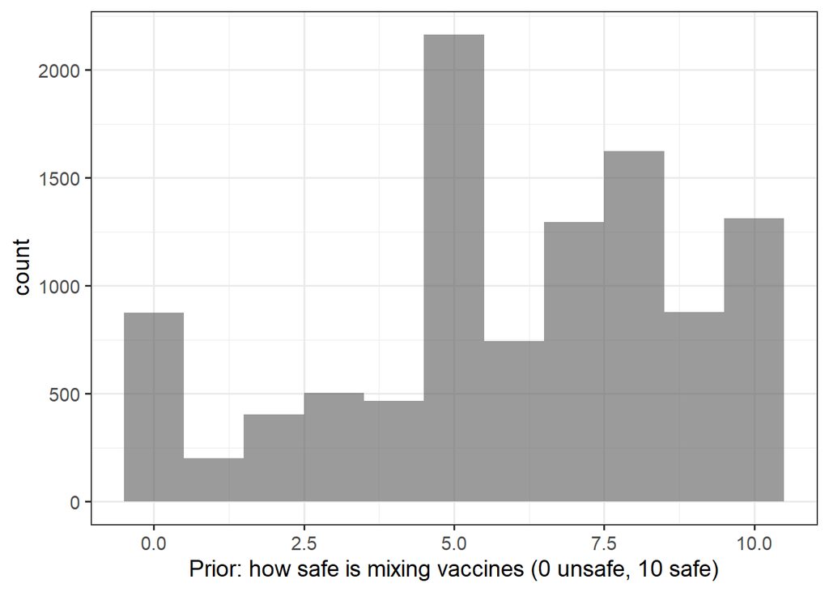

Public debate and prior attitudes towards vaccine mixing.

```r
prior_mixed_hist <- thirdwave |>
  ggplot(aes(prior_mixed)) +
  geom_histogram(binwidth = 1, alpha = 0.6) +
  xlab("Prior: how safe is mixing vaccines (0 unsafe, 10 safe)") +
  theme_bw(base_size = 14)

prior_mixed_hist
```

```r
ggsave(file.path(fig_dir, "fig_1_priors_hist.pdf"), prior_mixed_hist, width = 6, height = 4)
```

## 4.2 Figure. Raw data patterns

Belief / Behave are conviction of and willingness to follow the **second message**, not support for mixing.

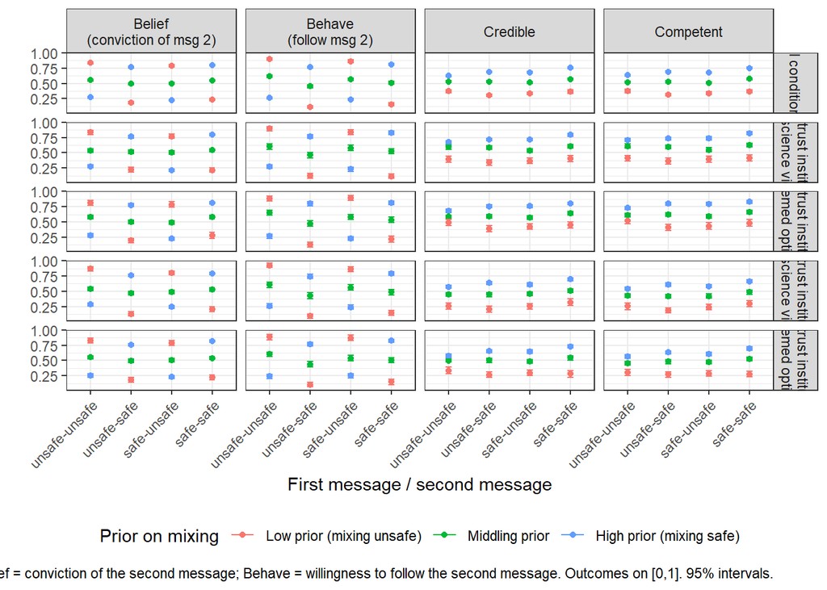

Raw data patterns disaggregated by priors. Belief is conviction of the second message; Behave is willingness to follow the second message.

```r
summary_data <-
  thirdwave |>
  mutate(
    prior = recode(as.character(prior_g), !!!prior_lab_long),
    science = info_treat,
    trust = sender_treat,
    Z = paste0(safe_time1, "/", safe_time2)
  ) |>
  transmute(
    safe_time1, safe_time2, science, trust, Z, prior,
    credible = as.numeric(credible),
    competent = as.numeric(competent),
    correct = as.numeric(correct),
    convinced = as.numeric(convinced_of_message_2),
    act = as.numeric(behave_as_message_2)
  ) |>
  pivot_longer(
    c(convinced, credible, act, competent, correct),
    names_to = "Y",
    values_to = "val"
  ) |>
  group_by(safe_time1, safe_time2, science, trust, Z, Y, prior) |>
  summarise(
    n = sum(!is.na(val)),
    mean = mean(val, na.rm = TRUE),
    sd = sd(val, na.rm = TRUE),
    se = sd / sqrt(n),
    tcrit = qt(0.975, df = pmax(n - 1, 1)),
    lwr = mean - tcrit * se,
    upr = mean + tcrit * se,
    .groups = "drop"
  ) |>
  mutate(
    trust_lab = if_else(trust == 1, "high-trust institution", "low-trust institution"),
    science_lab = science_lab(science),
    cond = paste(trust_lab, science_lab, sep = "\n"),
    cond = factor(
      cond,
      levels = c(
        paste("high-trust institution", science_lab(0), sep = "\n"),
        paste("high-trust institution", science_lab(1), sep = "\n"),
        paste("low-trust institution", science_lab(0), sep = "\n"),
        paste("low-trust institution", science_lab(1), sep = "\n")
      )
    ),
    Z = recode(
      Z,
      "0/0" = "unsafe-unsafe",
      "0/1" = "unsafe-safe",
      "1/0" = "safe-unsafe",
      "1/1" = "safe-safe"
    ),
    Z = factor(Z, c("unsafe-unsafe", "unsafe-safe", "safe-unsafe", "safe-safe"))
  )

all_row <- summary_data |>
  group_by(safe_time1, safe_time2, Z, Y, prior) |>
  summarise(
    N = sum(n),
    mu = sum(mean * n) / N,
    var_num = sum((n - 1) * sd^2 + n * (mean - mu)^2),
    sd = sqrt(var_num / pmax(N - 1, 1)),
    se = sd / sqrt(N),
    tcrit = qt(0.975, df = pmax(N - 1, 1)),
    lwr = mu - tcrit * se,
    upr = mu + tcrit * se,
    .groups = "drop"
  ) |>
  transmute(
    safe_time1, safe_time2, Z, Y, prior,
    n = N, mean = mu, sd, se, tcrit, lwr, upr,
    trust_lab = NA_character_, science_lab = NA_character_,
    cond = factor("All conditions", levels = c("All conditions", levels(summary_data$cond)))
  )

summary_data <- bind_rows(
  all_row,
  summary_data |> mutate(cond = fct_relevel(cond, "All conditions"))
) |>
  mutate(
    Y = factor(
      Y,
      c("convinced", "act", "credible", "competent", "correct"),
      c("Belief\n(conviction of msg 2)", "Behave\n(follow msg 2)", "Credible", "Competent", "Correct")
    ),
    prior = factor(prior, unname(prior_lab_long))
  )

# Main-text raw figure: drop Correct (kept in appendix grids).
raw_main <- summary_data |>
  filter(as.character(Y) != "Correct") |>
  mutate(Y = droplevels(Y))

raw_patterns_disagg <-
  ggplot(raw_main, aes(x = Z, y = mean, color = prior)) +
  facet_grid(cond ~ Y, labeller = label_value) +
  geom_point() +
  geom_errorbar(aes(ymin = lwr, ymax = upr), width = 0.15) +
  theme_bw() +
  theme(
    axis.text.x = element_text(angle = 45, hjust = 1, vjust = 1),
    legend.position = "bottom"
  ) +
  labs(
    x = "First message / second message",
    y = "",
    color = "Prior on mixing",
    caption = "Belief = conviction of the second message; Behave = willingness to follow the second message. Outcomes on [0,1]. 95% intervals."
  )

raw_patterns_disagg
```

```r
ggsave(file.path(fig_dir, "fig_2_raw_disagg.pdf"), raw_patterns_disagg, width = 12, height = 9)
```

## 4.3 Table 2. Fully saturated model

PAP estimator. Four treatments, Lin-demeaned, **no hidden coefficients** (intercept omitted). Main effects are averages.

```r
saturated <- fit_saturated_list(thirdwave)
mean_ord <- mean(as.numeric(thirdwave$safe_time1), na.rm = TRUE)
mean_science <- mean(as.numeric(thirdwave$science), na.rm = TRUE)
mean_trusted <- mean(as.numeric(thirdwave$trusted), na.rm = TRUE)

tab_sat <- write_texreg(
  saturated[seq_len(4)],
  file = file.path(fig_dir, "tab_2_saturated.tex"),
  caption = "Fully saturated model. Treatments demeaned (Lin 2013); reported main effects are averages. Outcomes on $[0,1]$. Belief = conviction of the second message; Behave = willingness to follow the second message. Correct is reported in the appendix.",
  label = "table:saturated",
  names = mod_names_main
)

# Add H-label superscripts to hypothesis cells in the saturated table.
# Rows: Reversals (H1), Reversals×Science (H2), Reversals×Trusted (H3).
# Belief gets the a suffix; Credible gets the b suffix. Column positions are
# read off mod_names_main rather than hard-coded, since the display order of the
# outcomes is set once in the housekeeping chunk.
sat_tex <- readLines(file.path(fig_dir, "tab_2_saturated.tex"))
col_belief <- 1L + match("Belief", mod_names_main)
col_credible <- 1L + match("Credible", mod_names_main)

# For each target row, find the coefficient line (not SE line) and tag the
# Belief and Credible cells.
tag_hyp <- function(lines, row_pat, ha, hb) {
  for (i in seq_along(lines)) {
    if (!grepl(row_pat, lines[i], fixed = TRUE)) next
    # Skip SE lines (start with spaces then &)
    if (grepl("^\\s*&\\s*\\$\\(", lines[i])) next
    parts <- strsplit(lines[i], "&", fixed = TRUE)[[1]]
    if (length(parts) < max(col_belief, col_credible)) next
    # Append tiny superscript after the closing $ in Belief and Credible columns
    parts[col_belief] <- sub(
      "\\$\\s*$", paste0("$\\\\textsuperscript{\\\\tiny ", ha, "} "), parts[col_belief]
    )
    parts[col_credible] <- sub(
      "\\$\\s*$", paste0("$\\\\textsuperscript{\\\\tiny ", hb, "} "), parts[col_credible]
    )
    lines[i] <- paste(parts, collapse = "&")
    break
  }
  lines
}

sat_tex <- tag_hyp(sat_tex, "Reversals ($Z_r$)", "H1a", "H1b")
sat_tex <- tag_hyp(sat_tex, "Reversals $\\times$ Science", "H2a", "H2b")
sat_tex <- tag_hyp(sat_tex, "Reversals $\\times$ Trusted", "H3a", "H3b")

# Vertical rules only at ||: Belief, Behave || Credible, Competent
sat_tex <- sub(
  "\\\\begin\\{tabular\\}\\{[^}]+\\}",
  "\\\\begin{tabular}{l c c || c c}",
  sat_tex
)

# Horizontal rules after SE rows, separating coefficient blocks:
# 1. Hypothesis two-ways (Reversals, Rev×Science, Rev×Trusted)
# 2. Three main effects (First safe, Trusted, Science)
# 3. Remaining two-ways (Trusted×Science, Rev×First, Trusted×First, Science×First)
# 4. Three-ways and four-way
# Insert from the bottom so earlier insertions do not shift later targets.
insert_rule_after_se <- function(lines, coef_pat, exclude_pat = NULL) {
  idx <- grep(coef_pat, lines)
  if (!is.null(exclude_pat)) {
    idx <- idx[!grepl(exclude_pat, lines[idx])]
  }
  if (length(idx) < 1) return(lines)
  append(lines, "\\addlinespace[3pt]\\hline", after = idx[1] + 1)
}

sat_tex <- insert_rule_after_se(sat_tex, "Science .* First safe")
sat_tex <- insert_rule_after_se(sat_tex, "Science video")
sat_tex <- insert_rule_after_se(
  sat_tex, "Reversals .* Trusted\\b", "Science|First safe"
)

writeLines(sat_tex, file.path(fig_dir, "tab_2_saturated.tex"))
```

```r
texreg::htmlreg(
  saturated[seq_len(4)],
  include.ci = FALSE,
  custom.model.names = mod_names_main,
  caption = "Table 2. Fully saturated four-way model. Treatments demeaned (Lin 2013). Outcomes on [0,1]. Belief / Behave are recoded agreement with the second recommendation. Correct is in the appendix.",
  stars = c(0.01, 0.05, 0.1),
  digits = 3,
  custom.coef.map = full.coef.map,
  doctype = FALSE
)
```

Table 2. Fully saturated four-way model. Treatments demeaned (Lin 2013). Outcomes on [0,1]. Belief / Behave are recoded agreement with the second recommendation. Correct is in the appendix.

|  | Belief | Behave | Credible | Competent |
| --- | --- | --- | --- | --- |
| Reversals ($Z_r$) | -0.043*** | -0.037*** | -0.023*** | -0.025*** |
|  | (0.006) | (0.008) | (0.005) | (0.005) |
| Reversals $\times$ Science | -0.018 | -0.009 | 0.009 | 0.013 |
|  | (0.012) | (0.015) | (0.011) | (0.011) |
| Reversals $\times$ Trusted | -0.007 | -0.007 | -0.004 | -0.008 |
|  | (0.012) | (0.015) | (0.011) | (0.011) |
| First message safe ($Z_1$) | 0.004 | 0.012* | 0.034*** | 0.030*** |
|  | (0.006) | (0.008) | (0.005) | (0.005) |
| Trusted sender ($Z_t$) | 0.002 | 0.009 | 0.101*** | 0.151*** |
|  | (0.006) | (0.008) | (0.005) | (0.005) |
| Science video ($Z_s$) | 0.010* | 0.015** | 0.028*** | 0.034*** |
|  | (0.006) | (0.008) | (0.005) | (0.005) |
| Trusted $\times$ Science | 0.005 | 0.008 | 0.004 | 0.010 |
|  | (0.012) | (0.015) | (0.011) | (0.011) |
| Reversals $\times$ First safe | -0.289*** | -0.174*** | -0.079*** | -0.081*** |
|  | (0.012) | (0.015) | (0.011) | (0.011) |
| Trusted $\times$ First safe | -0.006 | -0.006 | -0.007 | -0.010 |
|  | (0.012) | (0.015) | (0.011) | (0.011) |
| Science $\times$ First safe | 0.015 | 0.008 | 0.006 | 0.003 |
|  | (0.012) | (0.015) | (0.011) | (0.011) |
| $Z_r \times Z_t \times Z_s$ | -0.040* | -0.022 | -0.010 | -0.010 |
|  | (0.024) | (0.030) | (0.021) | (0.022) |
| $Z_r \times Z_t \times Z_1$ | -0.027 | -0.014 | 0.027 | 0.036* |
|  | (0.024) | (0.030) | (0.021) | (0.022) |
| $Z_r \times Z_s \times Z_1$ | -0.003 | -0.001 | 0.012 | -0.005 |
|  | (0.024) | (0.030) | (0.021) | (0.022) |
| $Z_t \times Z_s \times Z_1$ | 0.031 | 0.019 | 0.024 | 0.020 |
|  | (0.024) | (0.030) | (0.021) | (0.022) |
| $Z_r \times Z_t \times Z_s \times Z_1$ | 0.014 | 0.010 | -0.004 | 0.012 |
|  | (0.048) | (0.060) | (0.043) | (0.044) |
| R<sup>2</sup> | 0.058 | 0.016 | 0.046 | 0.080 |
| Adj. R<sup>2</sup> | 0.057 | 0.014 | 0.044 | 0.079 |
| Num. obs. | 10456 | 10456 | 10456 | 10456 |
| RMSE | 0.306 | 0.385 | 0.274 | 0.281 |

***p < 0.01; **p < 0.05; *p < 0.1

## 4.4 Sequencing algebra and structural parameters $\beta_1$, $\beta_2$, and $\beta_r$

Paper order: seeming sequence split already in Table 2 (`inconsistent` vs `inconsistent × first-safe`); then the $\beta_1,\beta_2,\beta_r$ write-up and two $2\times 2$ arrays (`fig:two_by_twos`, TeX only); then this figure. The order-conditional coefficient grid (`fig_3_order_effects.pdf`) and mixed-message table (`tab_3_mixed_messages.tex`) are appendix, with the G order subsample tables.

One float, two stacked `plot_cond_grid` panels (`patchwork`, heights 3:2). **Top:** $\beta_r$, $\beta_r\times Z_s$, $\beta_r\times Z_t$, shared $x$ (`scales = "fixed"`). **Bottom:** $\beta_1$ and $\beta_2$ on **all four** main-text outcomes, including Belief and Behave; `scales = "free_x"`. **ALL** from `saturated` (Table 2). Prior colors from the **same** pooled four-treatment $\times$ prior-group model as the appendix prior grid (`saturated_prior`), not from subsample fits. Mapping (Lin-demeaned 0/1 treatments): $\beta_r=$ `inconsistent` $=Z_r$ (the coefficient directly; $\beta_r<0$ for a penalty); $\beta_r\times Z_s=$ `inconsistent:science`; $\beta_r\times Z_t=$ `inconsistent:trusted`; $\beta_1=$ `safe_time1` $=Z_1$; $\beta_2=$ $-\tfrac12\times$`inconsistent:safe_time1` $=-\tfrac12\times(Z_r\times Z_1)$. Dodge/legend: ALL, Low, Middling, High (not alphabetical); ALL at the top of each cluster. Shared legend at the bottom. H1a–H3b on the top-panel ALL points at Belief/Credible. The `saturated_prior` *fit* stays here because this figure needs it; only the prior-coefficient *plot* is with the appendix exhibits. Main-text column order is Belief, Behave, Credible, Competent on **both** panels; outcome strip labels on both. Correct is appendix-only.

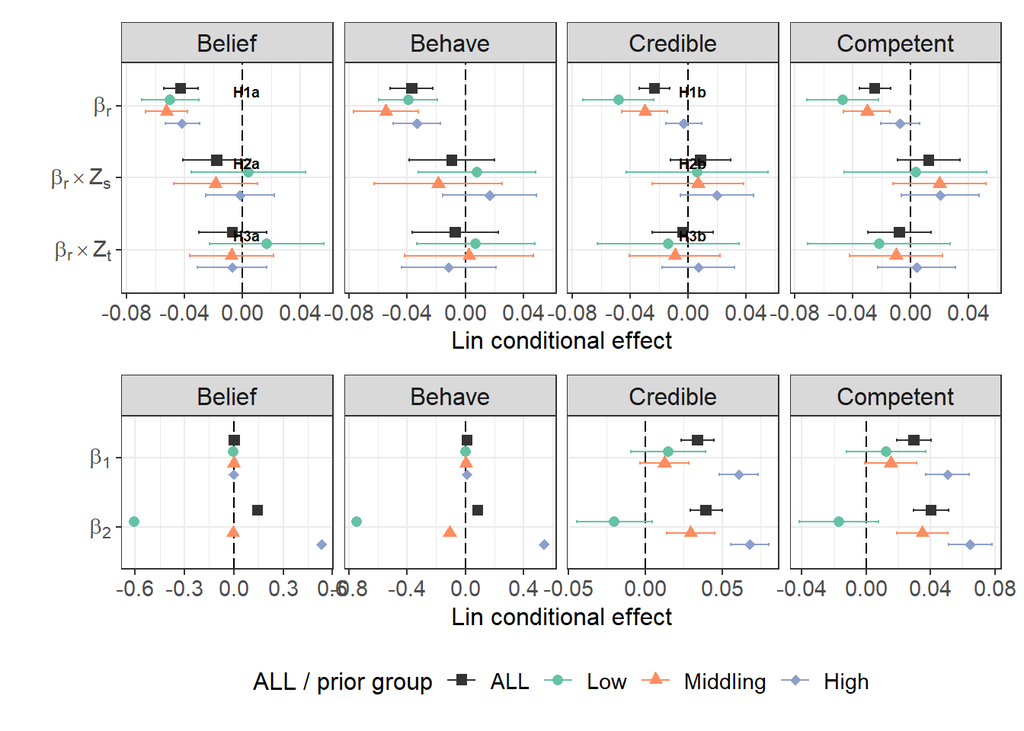

Structural parameters. Top: reversal penalty $\beta_r$ and science and trusted-sender shifts (shared $x$). Bottom: $\beta_1$ and $\beta_2$ on all four outcomes (free $x$).

```r
# Fit the prior-interacted model once here (appendix prior-grid plot reuses it).
if (!exists("saturated_prior")) {
  dat_prior <- thirdwave |>
    filter(!is.na(prior_g))
  prior_rhs <- "inconsistent * trusted * science * safe_time1 * prior_g"
  saturated_prior <- lapply(outcomes, function(y) {
    d <- with_demeaned_treatments(dat_prior, treatment_vars)
    lm_robust(as.formula(paste(y, "~", prior_rhs)), data = d)
  })
  prior_levels <- levels(dat_prior$prior_g)
  prior_mains <- grep("^prior_g", names(coef(saturated_prior[[1]])), value = TRUE)
  prior_mains <- prior_mains[!grepl(":", prior_mains)]
  prior_dummies <- setNames(rep(NA_character_, length(prior_levels)), prior_levels)
  for (nm in prior_mains) {
    lev <- sub("^prior_g", "", nm)
    if (lev %in% names(prior_dummies)) prior_dummies[[lev]] <- nm
  }
}

# R term names from inconsistent * trusted * science * safe_time1.
# One y-stack, this order (top to bottom after scale_y_discrete(limits = rev)).
effect_defs_abc <- tibble::tribble(
  ~effect, ~base, ~scale,
  "$\\beta_r$", "inconsistent", 1,
  "$\\beta_r \\times Z_s$", "inconsistent:science", 1,
  "$\\beta_r \\times Z_t$", "inconsistent:trusted", 1,
  "$\\beta_1$", "safe_time1", 1,
  "$\\beta_2$", "inconsistent:safe_time1", -0.5
) |>
  mutate(effect = factor(effect, unique(effect)))

scale_pairs <- function(pairs, scale) {
  setNames(as.numeric(pairs) * scale, names(pairs))
}

# Legend / factor order (not alphabetical): ALL, Low, Middling, High.
# Discrete-y dodge puts the first level at the *bottom* of a cluster;
# plot_cond_grid(..., dodge_reverse = TRUE) puts ALL at the top.
abc_series <- c("ALL", "Low", "Middling", "High")
prior_lab_abc <- c(low = "Low", mid = "Middling", high = "High")

abc_overall <- map2_dfr(saturated, outcome_labels, function(fit, lab) {
  map_dfr(seq_len(nrow(effect_defs_abc)), function(i) {
    sp <- effect_defs_abc[i, ]
    lincom_fit(fit, scale_pairs(pairs_at_group(sp$base, NA_character_), sp$scale)) |>
      mutate(
        outcome = lab,
        effect = sp$effect,
        series = "ALL"
      )
  })
})

abc_prior <- map2_dfr(saturated_prior, outcome_labels, function(fit, lab) {
  map_dfr(names(prior_dummies), function(g) {
    dum <- prior_dummies[[g]]
    map_dfr(seq_len(nrow(effect_defs_abc)), function(i) {
      sp <- effect_defs_abc[i, ]
      lincom_fit(fit, scale_pairs(pairs_at_group(sp$base, dum), sp$scale)) |>
        mutate(
          outcome = lab,
          effect = sp$effect,
          series = unname(prior_lab_abc[[g]])
        )
    })
  })
})

abc_dat <- bind_rows(abc_overall, abc_prior) |>
  mutate(
    outcome = factor(outcome, outcome_labels),
    series = factor(series, abc_series),
    effect = factor(effect, levels = levels(effect_defs_abc$effect))
  )

abc_main <- keep_main_outcomes(abc_dat)

effects_top <- c("$\\beta_r$", "$\\beta_r \\times Z_s$", "$\\beta_r \\times Z_t$")
effects_bot <- c("$\\beta_1$", "$\\beta_2$")
# Main-text columns, left to right. Re-applied immediately before ggplot;
# character outcome (e.g. after a join) makes facet_grid alphabetize.
abc_col_order <- outcome_labels_main
abc_top <- abc_main |>
  filter(as.character(effect) %in% effects_top) |>
  mutate(effect = factor(effect, effects_top))
abc_bot <- abc_main |>
  filter(as.character(effect) %in% effects_bot) |>
  mutate(effect = factor(effect, effects_bot))

abc_colors <- c(
  "ALL" = "grey20",
  "Low" = "#66c2a5",
  "Middling" = "#fc8d62",
  "High" = "#8da0cb"
)
abc_shapes <- c(
  "ALL" = 15,
  "Low" = 16,
  "Middling" = 17,
  "High" = 18
)

#
# Hypothesis labels on the ALL-series points at Belief/Credible × {β_r, β_r×Z_s, β_r×Z_t}.
#
abc_hyp_labels <- tibble::tribble(
  ~effect, ~outcome, ~label,
  "$\\beta_r$",            "Belief",   "H1a",
  "$\\beta_r$",            "Credible", "H1b",
  "$\\beta_r \\times Z_s$", "Belief",   "H2a",
  "$\\beta_r \\times Z_s$", "Credible", "H2b",
  "$\\beta_r \\times Z_t$", "Belief",   "H3a",
  "$\\beta_r \\times Z_t$", "Credible", "H3b"
)

abc_hyp_label_dat <- abc_top |>
  filter(series == "ALL") |>
  inner_join(abc_hyp_labels, by = c("effect", "outcome"))

# Immediately before ggplot: same factor on both panels and the H-label layer
# (inner_join with a character tribble otherwise drops the outcome factor).
abc_top <- abc_top |>
  mutate(outcome = factor(as.character(outcome), abc_col_order))
abc_bot <- abc_bot |>
  mutate(outcome = factor(as.character(outcome), abc_col_order))
abc_hyp_label_dat <- abc_hyp_label_dat |>
  mutate(outcome = factor(as.character(outcome), abc_col_order))

pos_abc <- position_dodge(width = 0.65, reverse = TRUE)

abc_scales_extra <- function(p, d) {
  p +
    scale_color_manual(values = abc_colors, breaks = abc_series) +
    scale_shape_manual(values = abc_shapes, breaks = abc_series) +
    scale_y_discrete(limits = rev, labels = latex2exp::TeX)
}

fig_abc_top <- plot_cond_grid(
  abc_top,
  color_var = "series",
  color_lab = "ALL / prior group",
  caption = NULL,
  dodge = 0.65,
  row_facets = FALSE,
  dodge_reverse = TRUE,
  scales = "fixed",
  extra = function(p, d) {
    abc_scales_extra(p, d) +
      geom_text(
        data = abc_hyp_label_dat,
        inherit.aes = FALSE,
        aes(x = 0.003, y = effect, label = label),
        position = pos_abc,
        size = 2.5,
        vjust = -0.8,
        fontface = "bold",
        show.legend = FALSE
      )
  }
)

fig_abc_bot <- plot_cond_grid(
  abc_bot,
  color_var = "series",
  color_lab = "ALL / prior group",
  caption = NULL,
  dodge = 0.65,
  row_facets = FALSE,
  dodge_reverse = TRUE,
  scales = "free_x",
  extra = abc_scales_extra
)

fig_abc <- fig_abc_top / fig_abc_bot +
  plot_layout(heights = c(3, 2), guides = "collect") &
  theme(legend.position = "bottom")

fig_abc
```

```r
ggsave(file.path(fig_dir, "fig_7_abc_parameters.pdf"), fig_abc, width = 11, height = 9)
```

```r
cat("Saturated (overall) terms:\n")
```

Saturated (overall) terms:

```r
cat(paste(setdiff(names(coef(saturated[[1]])), "(Intercept)"), collapse = "\n"))
```

inconsistent trusted science safe_time1 inconsistent:trusted inconsistent:science trusted:science inconsistent:safe_time1 trusted:safe_time1 science:safe_time1 inconsistent:trusted:science inconsistent:trusted:safe_time1 inconsistent:science:safe_time1 trusted:science:safe_time1 inconsistent:trusted:science:safe_time1

```r
cat("\n\nPrior-interacted bases used for beta_1, beta_2, beta_r:\n")
```

Prior-interacted bases used for beta_1, beta_2, beta_r:

```r
cat(paste(unique(effect_defs_abc$base), collapse = "\n"))
```

inconsistent inconsistent:science inconsistent:trusted safe_time1 inconsistent:safe_time1

```r
cat("\n\nN (overall saturated, Belief): ", nobs(saturated[[1]]), "\n", sep = "")
```

N (overall saturated, Belief): 10456

```r
cat("N (prior-interacted, Belief): ", nobs(saturated_prior[[1]]), "\n", sep = "")
```

N (prior-interacted, Belief): 10456

```r
abc_cred <- abc_dat |>
  filter(outcome == "Credible", series == "ALL") |>
  select(effect, estimate, se, conf.low, conf.high)
print(abc_cred, digits = 3)
```

# 5 A tibble: 5 × 5

effect estimate se conf.low conf.high 1 “$\\beta_r$” -0.0230 0.00535 -0.0335 -0.0125 2 “$\\beta_r \\times Z_s$” 0.00871 0.0107 -0.0123 0.0297 3 “$\\beta_r \\times Z_t$” -0.00372 0.0107 -0.0247 0.0173 4 “$\\beta_1$” 0.0340 0.00535 0.0235 0.0445 5 “$\\beta_2$” 0.0396 0.00535 0.0291 0.0501

```r
n_ab_bb <- abc_dat |>
  filter(effect %in% c("$\\beta_1$", "$\\beta_2$"), outcome %in% c("Belief", "Behave")) |>
  nrow()
cat("beta_1/beta_2 rows on Belief/Behave (expect 16): ", n_ab_bb, "\n", sep = "")
```

beta_1/beta_2 rows on Belief/Behave (expect 16): 16

```r
gb_abc <- ggplot_build(fig_abc_top)
xlims <- vapply(
  seq_along(gb_abc$layout$panel_params),
  function(i) {
    pp <- gb_abc$layout$panel_params[[i]]
    rng <- pp$x.range
    if (is.null(rng) && !is.null(pp$x)) {
      rng <- if (!is.null(pp$x$limits)) pp$x$limits else pp$x$range
    }
    paste(round(as.numeric(rng), 4), collapse = " to ")
  },
  character(1)
)
cat("top-panel x-ranges (should be identical):\n")
```

top-panel x-ranges (should be identical):

```r
print(unique(xlims))
```

[1] “-0.0834 to 0.0625”

```r
gb_bot <- ggplot_build(fig_abc_bot)
xlims_bot <- vapply(
  seq_along(gb_bot$layout$panel_params),
  function(i) {
    pp <- gb_bot$layout$panel_params[[i]]
    rng <- pp$x.range
    if (is.null(rng) && !is.null(pp$x)) {
      rng <- if (!is.null(pp$x$limits)) pp$x$limits else pp$x$range
    }
    paste(round(as.numeric(rng), 4), collapse = " to ")
  },
  character(1)
)
cat("bottom-panel x-ranges (free_x; Belief/Behave should be wider):\n")
```

bottom-panel x-ranges (free_x; Belief/Behave should be wider):

```r
print(xlims_bot)
```

[1] “-0.6826 to 0.6041” “-0.8329 to 0.6232” “-0.051 to 0.0868” [4] “-0.0476 to 0.0842”

```r
layout_cols <- function(p) {
  ly <- ggplot_build(p)$layout$layout
  as.character(ly$outcome[order(ly$COL)])
}
cat(
  "top-panel columns: ", paste(layout_cols(fig_abc_top), collapse = " | "), "\n",
  "bottom-panel columns: ", paste(layout_cols(fig_abc_bot), collapse = " | "), "\n",
  sep = ""
)
```

top-panel columns: Belief | Behave | Credible | Competent bottom-panel columns: Belief | Behave | Credible | Competent

```r
bot_strip <- fig_abc_bot$theme$strip.text.x
top_strip <- fig_abc_top$theme$strip.text.x
cat(
  "top strip.text.x blank: ", inherits(top_strip, "element_blank"), "\n",
  "bottom strip.text.x blank: ", inherits(bot_strip, "element_blank"), "\n",
  sep = ""
)
```

top strip.text.x blank: FALSE bottom strip.text.x blank: FALSE

```r
cat("\nabc factor / legend order: ", paste(abc_series, collapse = " | "), "\n", sep = "")
```

abc factor / legend order: ALL | Low | Middling | High

```r
eb <- gb_abc$data[[2]]
one <- eb[as.integer(eb$PANEL) == 1, ]
one <- one[one$y > max(one$y) - 0.7, ]
one <- one[order(-one$y), ]
src <- dplyr::filter(abc_top, outcome == "Belief", effect == "$\\beta_r$")
dodge_lab <- as.character(src$series[match(round(one$x, 8), round(src$estimate, 8))])
cat("abc visual top-to-bottom (Belief, beta_r): ", paste(dodge_lab, collapse = " | "), "\n", sep = "")
```

abc visual top-to-bottom (Belief, beta_r): ALL | Low | Middling | High

## 5.1 Figure. ITT and LATE

Four outcomes as Table 2 (Correct in the appendix). Assignment instruments perceived inconsistency.

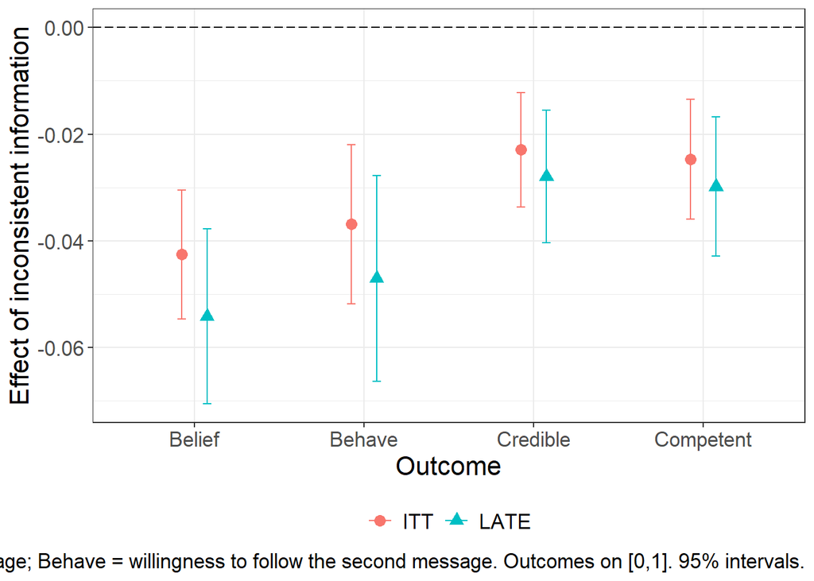

Intent-to-treat (ITT) and local average treatment (LATE) effect.

```r
models_basic <- lapply(outcomes, function(y) {
  lm_robust(as.formula(paste(y, "~ inconsistent")), data = thirdwave)
})
names(models_basic) <- outcomes

subfigure_1_itt <- lapply(models_basic, tidy) |>
  bind_rows(.id = "outcome") |>
  mutate(Model = "ITT") |>
  filter(term != "(Intercept)") |>
  mutate(outcome = factor(outcome, outcomes, outcome_labels)) |>
  select(-any_of("df"))

models_iv <- lapply(outcomes, function(y) {
  iv_robust(
    as.formula(paste(y, "~ treatment_measurement | inconsistent")),
    data = thirdwave
  )
})
names(models_iv) <- outcomes

subfigure_1_iv <- lapply(models_iv, tidy) |>
  bind_rows(.id = "outcome") |>
  mutate(Model = "LATE") |>
  filter(term != "(Intercept)") |>
  mutate(outcome = factor(outcome, outcomes, outcome_labels)) |>
  select(-any_of("df"))

data_figure5 <- bind_rows(subfigure_1_itt, subfigure_1_iv)

figure_itt <- keep_main_outcomes(data_figure5) |>
  ggplot(aes(estimate, outcome, color = Model, shape = Model)) +
  geom_point(position = position_dodge(width = 0.3), size = 3) +
  geom_errorbar(
    aes(xmin = conf.low, xmax = conf.high),
    position = position_dodge(width = 0.3),
    width = 0.1
  ) +
  geom_vline(xintercept = 0, linetype = "longdash") +
  xlab("Effect of inconsistent information") +
  ylab("Outcome") +
  labs(
    caption = "Belief = conviction of the second message; Behave = willingness to follow the second message. Outcomes on [0,1]. 95% intervals."
  ) +
  theme_bw() +
  theme(legend.position = "bottom", legend.title = element_blank(), text = element_text(size = 16)) +
  coord_flip()

figure_itt
```

```r
ggsave(file.path(fig_dir, "fig_4_itt_late.pdf"), figure_itt, width = 8, height = 5)
```

```r
show_htmlreg(
  models_basic[seq_len(4)],
  caption = "ITT companion. Reversal assignment. Same four outcomes as Table 2.",
  names = mod_names_main,
  coef_map = list("inconsistent" = "Reversals")
)
```

ITT companion. Reversal assignment. Same four outcomes as Table 2.

|  | Belief | Behave | Credible | Competent |
| --- | --- | --- | --- | --- |
| Reversals | -0.043*** | -0.037*** | -0.023*** | -0.025*** |
|  | (0.006) | (0.008) | (0.005) | (0.006) |
| R<sup>2</sup> | 0.005 | 0.002 | 0.002 | 0.002 |
| Adj. R<sup>2</sup> | 0.004 | 0.002 | 0.002 | 0.002 |
| Num. obs. | 10456 | 10456 | 10456 | 10456 |
| RMSE | 0.314 | 0.388 | 0.280 | 0.293 |

***p < 0.01; **p < 0.05; *p < 0.1

```r
show_htmlreg(
  models_iv[seq_len(4)],
  caption = "LATE/IV companion. Perceived inconsistency instrumented by assignment. Same four outcomes as Table 2.",
  names = mod_names_main,
  coef_map = iv_coef_map
)
```

LATE/IV companion. Perceived inconsistency instrumented by assignment. Same four outcomes as Table 2.

|  | Belief | Behave | Credible | Competent |
| --- | --- | --- | --- | --- |
| Perceived inconsistency | -0.054*** | -0.047*** | -0.028*** | -0.030*** |
|  | (0.008) | (0.010) | (0.006) | (0.007) |
| R<sup>2</sup> | -0.187 | -0.085 | 0.131 | 0.131 |
| Adj. R<sup>2</sup> | -0.187 | -0.085 | 0.131 | 0.131 |
| Num. obs. | 10357 | 10357 | 10357 | 10357 |
| RMSE | 0.344 | 0.404 | 0.261 | 0.273 |

***p < 0.01; **p < 0.05; *p < 0.1

## 5.2 Figure. Reversal conditional on science and trusted sender

From the **same** Table 2 fits (pooled Lin-saturated `inconsistent * trusted * science * safe_time1`). Row 1: effect of $Z_r$ at $Z_s=0$ and $Z_s=1$. Row 2: effect of $Z_r$ at $Z_t=0$ and $Z_t=1$. Other treatments at their means (demeaned evaluation of the 0/1 arm at raw 0 vs 1). Four main-text outcomes (Correct in appendix). No subsample models.

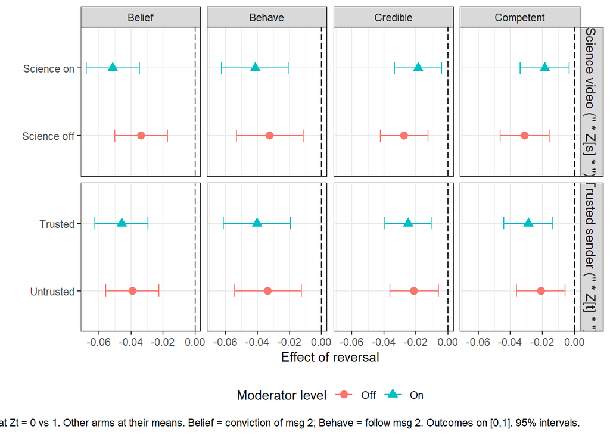

Effect of reversal conditional on the science-video arm (top) and the trusted-sender arm (bottom), from the Table 2 saturated model.

```r
science_me <- map2_dfr(saturated, outcome_labels, function(fit, lab) {
  sci <- map_dfr(c(0, 1), function(s) {
    s_d <- s - mean_science
    lincom_fit(fit, c(inconsistent = 1, `inconsistent:science` = s_d)) |>
      mutate(
        outcome = lab,
        moderator = "Science video ($Z_s$)",
        arm = if_else(s == 1, "Science on", "Science off"),
        z = s
      )
  })
  tr <- map_dfr(c(0, 1), function(t) {
    t_d <- t - mean_trusted
    lincom_fit(fit, c(inconsistent = 1, `inconsistent:trusted` = t_d)) |>
      mutate(
        outcome = lab,
        moderator = "Trusted sender ($Z_t$)",
        arm = if_else(t == 1, "Trusted", "Untrusted"),
        z = t
      )
  })
  bind_rows(sci, tr)
}) |>
  mutate(
    outcome = factor(outcome, outcome_labels),
    moderator = factor(
      moderator,
      c("Science video ($Z_s$)", "Trusted sender ($Z_t$)")
    ),
    arm = factor(
      arm,
      c("Science off", "Science on", "Untrusted", "Trusted")
    ),
    on = factor(z, levels = c(0, 1), labels = c("Off", "On"))
  )

fig_science <- keep_main_outcomes(science_me) |>
  ggplot(aes(estimate, arm, color = on, shape = on)) +
  geom_vline(xintercept = 0, linetype = "longdash") +
  geom_point(size = 2.8) +
  geom_errorbar(
    aes(xmin = conf.low, xmax = conf.high),
    orientation = "y",
    width = 0.18
  ) +
  facet_grid(
    moderator ~ outcome,
    scales = "free_y",
    labeller = labeller(
      moderator = latex2exp::TeX,
      outcome = identity
    )
  ) +
  xlab("Effect of reversal") +
  ylab("") +
  labs(
    color = "Moderator level",
    shape = "Moderator level",
    caption = "Lin-demeaned four-way (Table 2). Top: Zr at Zs = 0 vs 1. Bottom: Zr at Zt = 0 vs 1. Other arms at their means. Belief = conviction of msg 2; Behave = follow msg 2. Outcomes on [0,1]. 95% intervals."
  ) +
  theme_bw() +
  theme(
    legend.position = "bottom",
    strip.text.y = element_text(size = 11)
  )

fig_science
```

```r
ggsave(
  file.path(fig_dir, "fig_5_science_trust_conditional.pdf"),
  fig_science,
  width = 10,
  height = 6.5
)
```

# 6 5. SI / appendix exhibits

## 6.1 Theory figures

$\alpha$ is the probability that the **deemed-optimal** policy persists as evidence may change. Underlying optimality does not change. Ported from `theory.qmd`.

```r
p_11 <- function(p, a) p * a
p_10 <- function(p, a) p * (1 - a)
p_01 <- function(p, a) (1 - p) * (1 - a)
p_00 <- function(p, a) (1 - p) * a

p_c_11 <- function(p, a, q, r) {
  num <- p_11(p, a) * q
  denom <- p_11(p, a) * q +
    (p_00(p, a) * (1 - r)^2 + (p_01(p, a) + p_10(p, a)) * r * (1 - r) +
       p_11(p, a) * r^2) * (1 - q)
  num / denom
}

p_c_10 <- function(p, a, q, r) {
  num <- p_10(p, a) * q
  denom <- p_10(p, a) * q +
    ((p_00(p, a) + p_11(p, a)) * r * (1 - r) + p_01(p, a) * (1 - r)^2 +
       p_10(p, a) * r^2) * (1 - q)
  num / denom
}

p_c_01 <- function(p, a, q, r) {
  num <- p_01(p, a) * q
  denom <- p_01(p, a) * q +
    ((p_00(p, a) + p_11(p, a)) * r * (1 - r) + p_01(p, a) * r^2 +
       p_10(p, a) * (1 - r)^2) * (1 - q)
  num / denom
}

p_c_00 <- function(p, a, q, r) {
  num <- p_00(p, a) * q
  denom <- p_00(p, a) * q +
    (p_00(p, a) * r^2 + (p_01(p, a) + p_10(p, a)) * r * (1 - r) +
       p_11(p, a) * (1 - r)^2) * (1 - q)
  num / denom
}

p_1_11 <- function(p, a, q, r) {
  num <- p_11(p, a) * q +
    (p_01(p, a) * r * (1 - r) + p_11(p, a) * r^2) * (1 - q)
  denom <- p_11(p, a) * q +
    (p_00(p, a) * (1 - r)^2 + (p_01(p, a) + p_10(p, a)) * r * (1 - r) +
       p_11(p, a) * r^2) * (1 - q)
  num / denom
}

p_1_10 <- function(p, a, q, r) {
  num <- (r * (1 - r) * p_11(p, a) + (1 - r)^2 * p_01(p, a)) * (1 - q)
  denom <- p_10(p, a) * q +
    ((p_00(p, a) + p_11(p, a)) * r * (1 - r) + p_01(p, a) * (1 - r)^2 +
       p_10(p, a) * r^2) * (1 - q)
  num / denom
}

p_1_01 <- function(p, a, q, r) {
  num <- p_01(p, a) * q +
    (r * (1 - r) * p_11(p, a) + r^2 * p_01(p, a)) * (1 - q)
  denom <- p_01(p, a) * q +
    ((p_00(p, a) + p_11(p, a)) * r * (1 - r) + p_01(p, a) * r^2 +
       p_10(p, a) * (1 - r)^2) * (1 - q)
  num / denom
}

p_1_00 <- function(p, a, q, r) {
  num <- (p_01(p, a) * r * (1 - r) + p_11(p, a) * (1 - r)^2) * (1 - q)
  denom <- p_00(p, a) * q +
    (p_00(p, a) * r^2 + (p_01(p, a) + p_10(p, a)) * r * (1 - r) +
       p_11(p, a) * (1 - r)^2) * (1 - q)
  num / denom
}

df2 <- expand_grid(
  p = c(.05, .25, .5, .75, .95),
  a = c(.51, .625, .75, .875, .95),
  q = seq(.05, .95, length = 25),
  r = 2 / 3
) |>
  mutate(
    c_11 = p_c_11(p, a, q, r),
    c_10 = p_c_10(p, a, q, r),
    c_01 = p_c_01(p, a, q, r),
    c_00 = p_c_00(p, a, q, r),
    pol_1_11 = p_1_11(p, a, q, r),
    pol_1_10 = p_1_10(p, a, q, r),
    pol_1_01 = p_1_01(p, a, q, r),
    pol_1_00 = p_1_00(p, a, q, r)
  ) |>
  # Belief in the second recommendation: P(w_2 = j | messages i, j).
  # Theory analogue of the Belief outcome, so paths ending in 0 are flipped.
  mutate(
    b2_11 = pol_1_11,
    b2_01 = pol_1_01,
    b2_10 = 1 - pol_1_10,
    b2_00 = 1 - pol_1_00
  ) |>
  # Reversal contrasts, holding the first message fixed.
  mutate(
    inc_b2_first0 = b2_01 - b2_00,
    inc_b2_first1 = b2_10 - b2_11,
    inc_c_first0 = c_01 - c_00,
    inc_c_first1 = c_10 - c_11
  ) |>
  # The same credibility contrasts in log odds. Since
  # logit(c_ij) = logit(q) - log(L_ij / p_ij), these do not depend on q.
  mutate(
    inc_lo_first0 = qlogis(c_01) - qlogis(c_00),
    inc_lo_first1 = qlogis(c_10) - qlogis(c_11)
  )

# Strip labels, theme, and the reversal-figure recipe, shared by the theory
# figures. The extra horizontal panel spacing keeps the "1.0" tick label of one
# facet column clear of the "0.0" of the next across five columns.
theory_theme <- function() {
  theme_bw() + theme(panel.spacing.x = unit(1, "lines"))
}

theory_lab_a <- function(x) {
  factor(x, unique(x), latex2exp::TeX(paste0("$\\alpha = ", unique(x), "$")))
}

theory_lab_p <- function(x) {
  factor(x, unique(x), latex2exp::TeX(paste0("$p = ", unique(x), "$")))
}

# Long form for a reversal figure: the two conditional contrasts plus their
# unweighted mean, the analogue of the pooled beta_r under 50/50 assignment.
theory_reversal_long <- function(d, v_first0, v_first1) {
  d |>
    select(p, a, q, first0 = all_of(v_first0), first1 = all_of(v_first1)) |>
    mutate(avg = (first0 + first1) / 2) |>
    pivot_longer(c(first0, first1, avg), names_to = "start", values_to = "val") |>
    mutate(start = factor(
      start,
      c("first0", "first1", "avg"),
      c("Reversal | first message 0", "Reversal | first message 1", "Average")
    ))
}

theory_reversal_plot <- function(d, ylab) {
  d |>
    mutate(a = theory_lab_a(a), p = theory_lab_p(p)) |>
    ggplot(aes(q, val, color = start)) +
    geom_hline(yintercept = 0, linetype = "longdash", color = "grey40") +
    geom_line() +
    facet_grid(a ~ p, labeller = label_parsed) +
    ylab(ylab) +
    xlab("q: prior confidence in authority") +
    labs(
      color = "",
      caption = "r = 2/3. Each contrast holds the first message fixed."
    ) +
    theory_theme() +
    scale_x_continuous(breaks = seq(0, 1, by = 0.25))
}
```

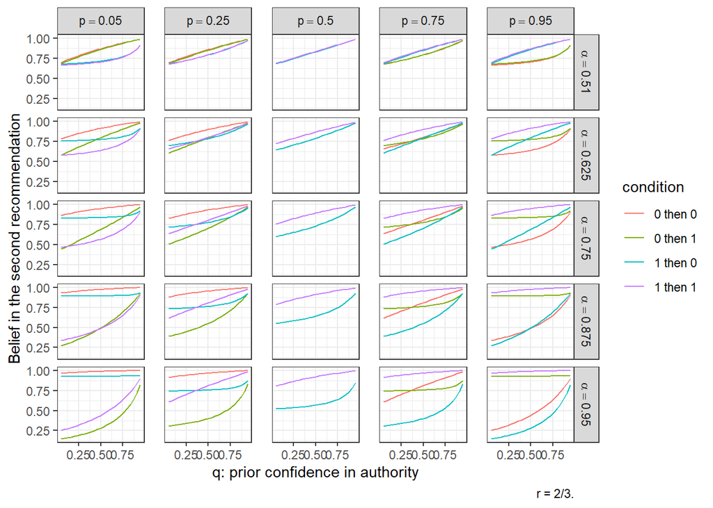

Figure 1: Theoretical predictions for belief in the second recommendation.

```r
fig_belief <-
  df2 |>
  select(p, a, q, r, b2_11, b2_10, b2_01, b2_00) |>
  pivot_longer(
    c(b2_11, b2_10, b2_01, b2_00),
    names_to = "condition",
    values_to = "val"
  ) |>
  mutate(
    condition = factor(
      condition,
      c("b2_00", "b2_01", "b2_10", "b2_11"),
      c("0 then 0", "0 then 1", "1 then 0", "1 then 1")
    ),
    a = theory_lab_a(a),
    p = theory_lab_p(p)
  ) |>
  ggplot(aes(q, val, color = condition)) +
  geom_line() +
  facet_grid(a ~ p, labeller = label_parsed) +
  ylab("Belief in the second recommendation") +
  xlab("q: prior confidence in authority") +
  labs(caption = "r = 2/3.") +
  theory_theme() +
  scale_x_continuous(breaks = seq(0, 1, by = 0.25))

fig_belief
ggsave(
  file.path(fig_dir, "fig_a1_policy.pdf"),
  fig_belief,
  width = 10,
  height = 6,
  device = cairo_pdf
)
```

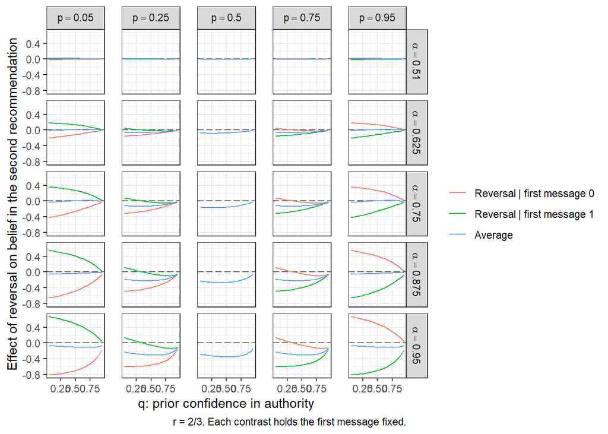

Figure 2: Theoretical effect of a reversal on belief in the second recommendation, by first message.

```r
fig_policy_reversal <-
  df2 |>
  theory_reversal_long("inc_b2_first0", "inc_b2_first1") |>
  theory_reversal_plot("Effect of reversal on belief in the second recommendation")

fig_policy_reversal
ggsave(
  file.path(fig_dir, "fig_a2_policy_reversal.pdf"),
  fig_policy_reversal,
  width = 10,
  height = 6,
  device = cairo_pdf
)
```

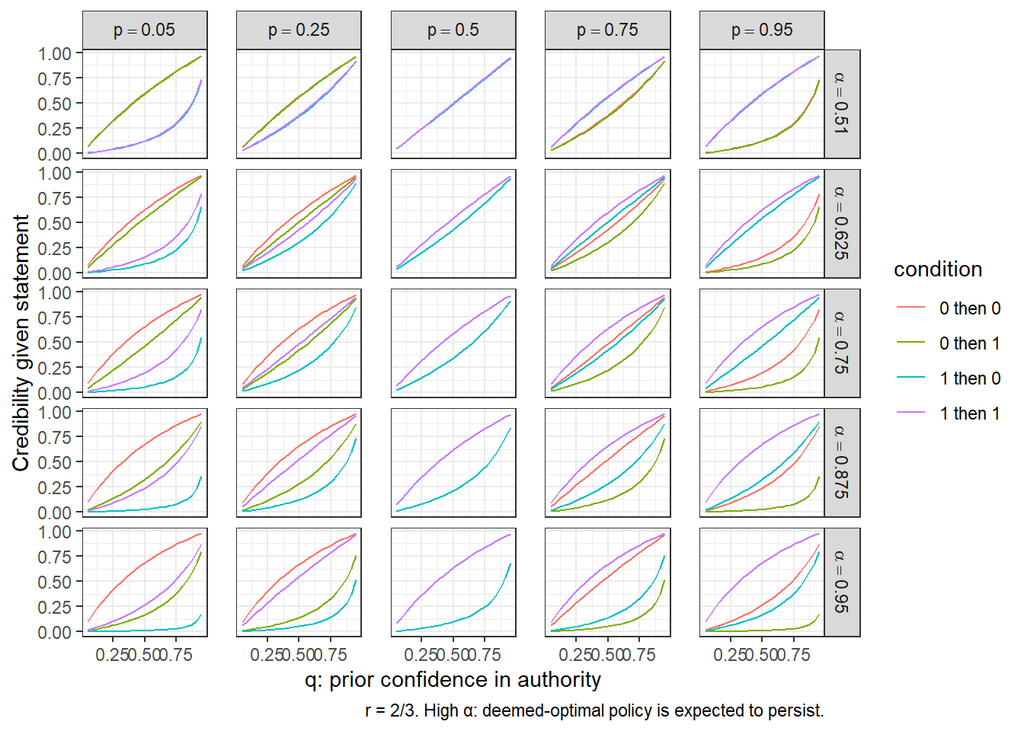

Figure 3: Theoretical predictions for credibility. α = P(deemed-optimal policy persists); underlying optimality is fixed.

```r
fig_credibility <-
  df2 |>
  select(p, a, q, r, c_11, c_10, c_01, c_00) |>
  pivot_longer(c(c_11, c_10, c_01, c_00), names_to = "condition", values_to = "val") |>
  mutate(
    condition = factor(
      condition,
      c("c_00", "c_01", "c_10", "c_11"),
      c("0 then 0", "0 then 1", "1 then 0", "1 then 1")
    ),
    a = factor(a, unique(a), latex2exp::TeX(paste0("$\\alpha = ", unique(a), "$"))),
    p = factor(p, unique(p), latex2exp::TeX(paste0("$p = ", unique(p), "$")))
  ) |>
  ggplot(aes(q, val, color = condition)) +
  geom_line() +
  facet_grid(a ~ p, labeller = label_parsed) +
  ylab("Credibility given statement") +
  xlab("q: prior confidence in authority") +
  labs(caption = "r = 2/3. High α: deemed-optimal policy is expected to persist.") +
  theory_theme() +
  scale_x_continuous(breaks = seq(0, 1, by = 0.25))

fig_credibility
ggsave(
  file.path(fig_dir, "fig_a3_credibility.pdf"),
  fig_credibility,
  width = 10,
  height = 6,
  device = cairo_pdf
)
```

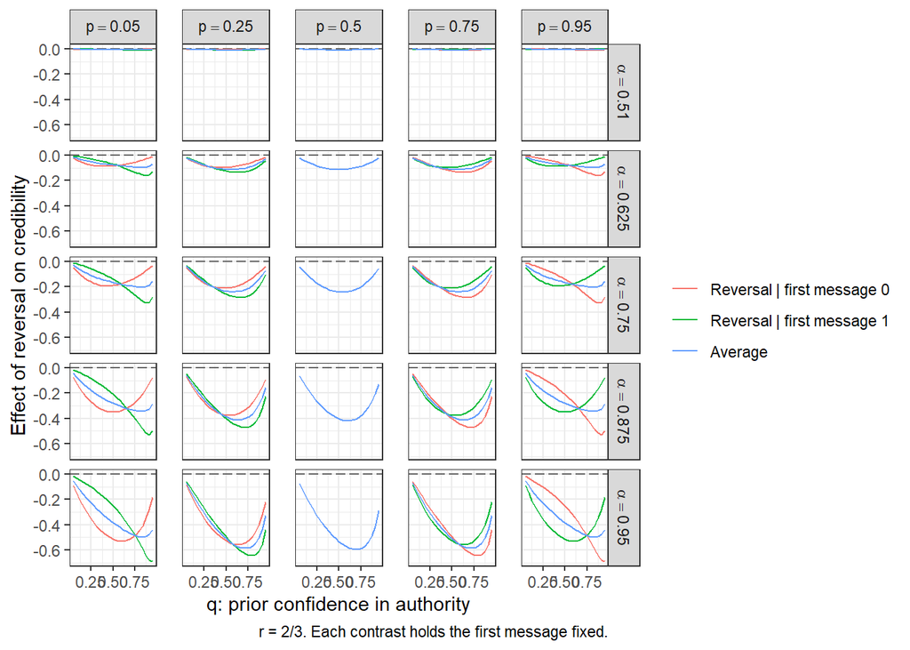

Figure 4: Theoretical effect of a reversal on credibility, by first message.

```r
fig_credibility_reversal <-
  df2 |>
  theory_reversal_long("inc_c_first0", "inc_c_first1") |>
  theory_reversal_plot("Effect of reversal on credibility")

fig_credibility_reversal
ggsave(
  file.path(fig_dir, "fig_a4_credibility_reversal.pdf"),
  fig_credibility_reversal,
  width = 10,
  height = 6,
  device = cairo_pdf
)
```

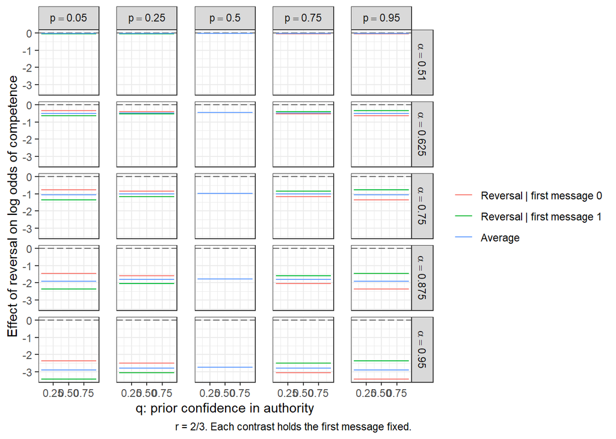

Figure 5: Theoretical effect of a reversal on the log odds of competence, by first message.

```r
fig_credibility_reversal_logodds <-
  df2 |>
  theory_reversal_long("inc_lo_first0", "inc_lo_first1") |>
  theory_reversal_plot("Effect of reversal on log odds of competence")

fig_credibility_reversal_logodds
ggsave(
  file.path(fig_dir, "fig_a5_credibility_reversal_logodds.pdf"),
  fig_credibility_reversal_logodds,
  width = 10,
  height = 6,
  device = cairo_pdf
)
```

### 6.1.1 Theoretical analogue of the $\beta_1$ / $\beta_2$ / $\beta_r$ figure

Reads the model at the paper’s own design points and pushes it through the same saturated decomposition as `fig_7_abc_parameters.pdf`, so the theory can be read for **sign and ordering** against the main-text figure. Magnitudes are not comparable: theoretical outcomes are posterior probabilities, empirical ones are 0–10 ratings rescaled to $[0,1]$.

Direction of $Z_s$. Table 1 defines $Z_s = 1$ as the video teaching that changing evidence is normal science, and $\alpha$ is the probability the deemed-optimal policy *persists*. The video therefore moves citizens to **low** $\alpha$: $Z_s = 1 \leftrightarrow \alpha = 0.6$, $Z_s = 0 \leftrightarrow \alpha = 0.9$, and $\beta_r \times Z_s$ is the $\alpha = 0.6$ minus $\alpha = 0.9$ difference. Taking it the other way round would make the model predict that the video *aggravates* the credibility penalty, the reverse of H2b. $Z_t = 1$ is the trusted sender, $q = 0.8$.

```r
ts_a_science <- 0.6    # Z_s = 1: the video lowers expected persistence
ts_a_control <- 0.9    # Z_s = 0
ts_q_trusted <- 0.8    # Z_t = 1
ts_q_untrusted <- 0.2  # Z_t = 0
ts_r <- 2 / 3

# p at the midpoints of the paper's prior cuts (3.3 / 6.6 on 0-10, rescaled).
ts_prior_vals <- c(Low = 0.165, Middling = 0.495, High = 0.83)
# Empirical prior-group shares, n = 1978 / 3373 / 5105 of 10456: the ALL series
# is the pooled estimate, hence size-weighted, not an unweighted average.
ts_prior_w <- c(Low = 0.189, Middling = 0.323, High = 0.488)
ts_series_order <- c("ALL", "Low", "Middling", "High")

ts_cells <- expand_grid(
  prior = names(ts_prior_vals),
  a = c(ts_a_science, ts_a_control),
  q = c(ts_q_untrusted, ts_q_trusted)
) |>
  mutate(p = unname(ts_prior_vals[prior]), r = ts_r) |>
  mutate(
    c_11 = p_c_11(p, a, q, r),
    c_10 = p_c_10(p, a, q, r),
    c_01 = p_c_01(p, a, q, r),
    c_00 = p_c_00(p, a, q, r),
    pol_11 = p_1_11(p, a, q, r),
    pol_10 = p_1_10(p, a, q, r),
    pol_01 = p_1_01(p, a, q, r),
    pol_00 = p_1_00(p, a, q, r)
  ) |>
  # Belief coding of the theory-helpers chunk: P(w_2 = j | messages i, j).
  mutate(
    b2_11 = pol_11,
    b2_01 = pol_01,
    b2_10 = 1 - pol_10,
    b2_00 = 1 - pol_00
  )

# Message pair (i, j): i first, j second; 1 = "mixing is safe", the policy whose
# prior probability of being optimal is p. Experimental coding is Z_1 = i and
# Z_r = 1{i != j}, matching safe_time1 and inconsistent. Saturated cell means
# Y = a + b_r Z_r + b_1 Z_1 + b_x Z_r Z_1 give Y(0,1) - Y(0,0) = b_r and
# Y(1,0) - Y(1,1) = b_r + b_x, and the Lin-demeaned coefficients of
# fig_7_abc_parameters.pdf are the 50/50 averages b_r + b_x/2, b_1 + b_x/2,
# and -b_x/2.
ts_structural <- function(y00, y01, y10, y11) {
  d_first0 <- y01 - y00
  d_first1 <- y10 - y11
  tibble(
    beta_r = (d_first0 + d_first1) / 2,
    beta_2 = (d_first0 - d_first1) / 2,
    beta_1 = ((y11 - y00) + (y10 - y01)) / 2
  )
}

ts_cell_params <- bind_rows(
  bind_cols(
    ts_cells |> select(prior, p, a, q),
    ts_structural(ts_cells$b2_00, ts_cells$b2_01, ts_cells$b2_10, ts_cells$b2_11)
  ) |>
    mutate(
      outcome = "Belief",
      ybar_support = (ts_cells$pol_00 + ts_cells$pol_01 +
                        ts_cells$pol_10 + ts_cells$pol_11) / 4
    ),
  bind_cols(
    ts_cells |> select(prior, p, a, q),
    ts_structural(ts_cells$c_00, ts_cells$c_01, ts_cells$c_10, ts_cells$c_11)
  ) |>
    mutate(outcome = "Credible", ybar_support = NA_real_)
)

# Checks reported in the appendix note for this figure.
ts_bel <- filter(ts_cell_params, outcome == "Belief")
ts_checks <- c(
  # Because Z_2 = Z_1 + Z_r - 2 Z_1 Z_r and Belief is coded relative to the
  # second message, beta_2 on Belief is 2 * mean support - 1: near-definitional.
  beta2_identity = max(abs(ts_bel$beta_2 - (2 * ts_bel$ybar_support - 1))),
  # The credibility reversal contrast is q-invariant in log odds, so any trust
  # shift on Credible is probability-scale compression, not evidentiary force.
  logodds_q_spread = ts_cells |>
    mutate(
      lo = ((qlogis(c_01) - qlogis(c_00)) + (qlogis(c_10) - qlogis(c_11))) / 2
    ) |>
    group_by(prior, a) |>
    summarise(spread = max(lo) - min(lo), .groups = "drop") |>
    pull(spread) |>
    max(),
  # Proposition: beta_r is invariant to p <-> 1-p, beta_1 and beta_2 flip sign.
  symmetry = local({
    g <- expand_grid(
      p = seq(0.02, 0.98, by = 0.01),
      a = seq(0.50, 0.99, by = 0.01),
      q = seq(0.02, 0.98, by = 0.02),
      r = c(0.5001, 0.55, 2 / 3, 0.75, 0.9, 0.99)
    )
    bet <- function(p) {
      o10 <- p_1_10(p, g$a, g$q, g$r)
      o00 <- p_1_00(p, g$a, g$q, g$r)
      list(
        cred = ts_structural(
          p_c_00(p, g$a, g$q, g$r), p_c_01(p, g$a, g$q, g$r),
          p_c_10(p, g$a, g$q, g$r), p_c_11(p, g$a, g$q, g$r)
        ),
        bel = ts_structural(
          1 - o00, p_1_01(p, g$a, g$q, g$r), 1 - o10, p_1_11(p, g$a, g$q, g$r)
        )
      )
    }
    A <- bet(g$p)
    B <- bet(1 - g$p)
    max(
      abs(B$cred$beta_r - A$cred$beta_r), abs(B$cred$beta_1 + A$cred$beta_1),
      abs(B$cred$beta_2 + A$cred$beta_2), abs(B$bel$beta_r - A$bel$beta_r),
      abs(B$bel$beta_1 + A$bel$beta_1), abs(B$bel$beta_2 + A$bel$beta_2)
    )
  })
)
print(signif(ts_checks, 3))
```

```
  beta2_identity logodds_q_spread         symmetry
        1.67e-16         5.55e-16         6.66e-16
```

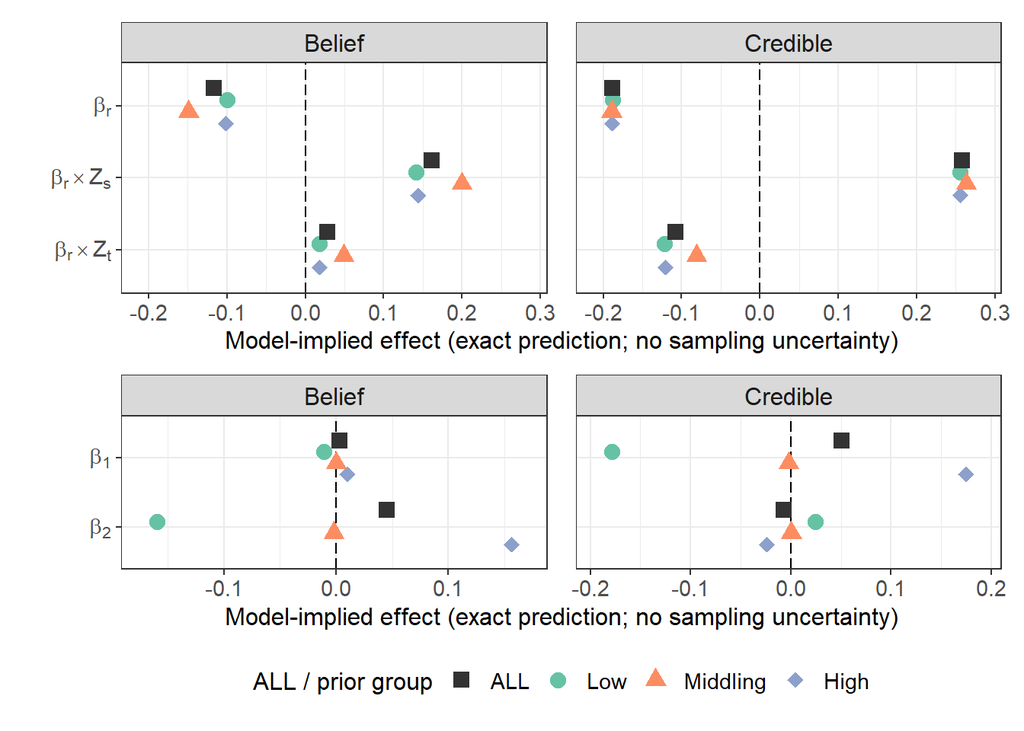

Figure 6: Model-implied β₁, β₂, βᵣ at the paper’s design points. Exact predictions; no sampling uncertainty.

```r
# Z_s and Z_t are assigned 50/50, so a main effect is the unweighted mean over
# the four (alpha, q) cells and the shifts are treated minus control arm means.
ts_summarise <- function(d) {
  d |>
    summarise(
      across(
        c(beta_1, beta_2, beta_r),
        list(
          base = ~ mean(.x),
          Zs = ~ mean(.x[a == ts_a_science]) - mean(.x[a == ts_a_control]),
          Zt = ~ mean(.x[q == ts_q_trusted]) - mean(.x[q == ts_q_untrusted])
        ),
        .names = "{.col}|{.fn}"
      ),
      .groups = "drop"
    )
}

ts_by_prior <- ts_cell_params |>
  group_by(outcome, prior) |>
  ts_summarise()

ts_all <- ts_by_prior |>
  group_by(outcome) |>
  summarise(
    across(contains("|"), ~ sum(.x * unname(ts_prior_w[prior]))),
    .groups = "drop"
  ) |>
  mutate(prior = "ALL")

ts_params <- bind_rows(ts_by_prior, ts_all) |>
  pivot_longer(
    contains("|"),
    names_to = c("param", "arm"),
    names_sep = "\\|",
    values_to = "estimate"
  )

ts_top <- c("$\\beta_r$", "$\\beta_r \\times Z_s$", "$\\beta_r \\times Z_t$")
ts_bot <- c("$\\beta_1$", "$\\beta_2$")

ts_plot_dat <- ts_params |>
  mutate(
    effect = case_when(
      param == "beta_r" & arm == "base" ~ ts_top[1],
      param == "beta_r" & arm == "Zs" ~ ts_top[2],
      param == "beta_r" & arm == "Zt" ~ ts_top[3],
      param == "beta_1" & arm == "base" ~ ts_bot[1],
      param == "beta_2" & arm == "base" ~ ts_bot[2],
      TRUE ~ NA_character_
    )
  ) |>
  filter(!is.na(effect)) |>
  mutate(
    series = factor(prior, ts_series_order),
    outcome = factor(outcome, c("Belief", "Credible"))
  )

ts_colors <- c(
  "ALL" = "grey20", "Low" = "#66c2a5",
  "Middling" = "#fc8d62", "High" = "#8da0cb"
)
ts_shapes <- c("ALL" = 15, "Low" = 16, "Middling" = 17, "High" = 18)

# Same grammar as fig_7_abc_parameters.pdf, minus the error bars: every point is
# an exact prediction, so points are drawn large and solid to make the absence
# of intervals read as deliberate rather than as a dropped layer. Generous x
# expansion plus n.breaks = 5 and the extra panel spacing of theory_theme()
# keeps the last tick label of one facet column clear of the first of the next.
ts_panel <- function(d, effect_levels, scales) {
  d <- d |> mutate(effect = factor(effect, effect_levels))
  ggplot(d, aes(x = estimate, y = effect, color = series, shape = series)) +
    geom_vline(xintercept = 0, linetype = "longdash") +
    geom_point(
      position = position_dodge(width = 0.65, reverse = TRUE),
      size = 3.1,
      stroke = 0.9
    ) +
    facet_grid(. ~ outcome, scales = scales) +
    scale_color_manual(values = ts_colors, breaks = ts_series_order) +
    scale_shape_manual(values = ts_shapes, breaks = ts_series_order) +
    scale_y_discrete(limits = rev, labels = latex2exp::TeX) +
    scale_x_continuous(n.breaks = 5, expand = expansion(mult = 0.10)) +
    xlab("Model-implied effect (exact prediction; no sampling uncertainty)") +
    ylab("") +
    labs(color = "ALL / prior group", shape = "ALL / prior group") +
    theory_theme() +
    theme(
      axis.text.x = element_text(size = 11),
      axis.text.y = element_text(size = 11),
      axis.title = element_text(size = 12),
      strip.text = element_text(size = 12),
      legend.text = element_text(size = 11),
      legend.title = element_text(size = 12),
      legend.position = "bottom"
    )
}

fig_theory_structural <-
  ts_panel(filter(ts_plot_dat, effect %in% ts_top), ts_top, "fixed") /
  ts_panel(filter(ts_plot_dat, effect %in% ts_bot), ts_bot, "free_x") +
  plot_layout(heights = c(3, 2), guides = "collect") &
  theme(legend.position = "bottom")

fig_theory_structural
ggsave(
  file.path(fig_dir, "fig_a6_theory_structural.pdf"),
  fig_theory_structural,
  width = 9,
  # Kept short: at \linewidth the float also has to carry a long floatfoot, and
  # a taller graphic makes the whole float exceed \textheight and never place.
  height = 6.2,
  device = cairo_pdf
)
```

## 6.2 Table B.1. OxCGRT (Government Response Index)

Motivational, not a second finding. Printed coefficients are the **Government Response Index** (GRI), $N=65$.

```r
oxcgrt_raw <- if (nzchar(oxcgrt_csv) && file.exists(oxcgrt_csv)) {
  read.csv(oxcgrt_csv)
} else {
  read.csv(oxcgrt_url)
}
oxcgrt_raw <- transform(oxcgrt_raw, Date = as.Date(as.character(Date), "%Y%m%d"))

policy_variables <- c(
  "ContainmentHealthIndex",
  "StringencyIndex",
  "GovernmentResponseIndex",
  "C1_School.closing",
  "C2_Workplace.closing",
  "C3_Cancel.public.events",
  "C4_Restrictions.on.gatherings",
  "C5_Close.public.transport",
  "C6_Stay.at.home.requirements",
  "C7_Restrictions.on.internal.movement",
  "C8_International.travel.controls",
  "H1_Public.information.campaigns",
  "H2_Testing.policy",
  "H3_Contact.tracing",
  "H6_Facial.Coverings",
  "H7_Vaccination.policy",
  "H8_Protection.of.elderly.people"
)

oxcgrt_daily <- oxcgrt_raw |>
  subset(Date < as.Date("2020-05-29")) |>
  dplyr::filter(Jurisdiction == "NAT_TOTAL") |>
  dplyr::select(CountryCode, CountryName, Date, dplyr::any_of(policy_variables))

election <- read_dta(election_file) |>
  dplyr::select(
    countryname,
    timetocase1,
    maxconsecutiveterms,
    termlength,
    canrun,
    electionproximity_yrs,
    electionproximity_yrs_canrun,
    Z_bci_bci,
    Z_cspf_sfi
  )

oxcgrt_merged <- merge(
  oxcgrt_daily,
  election,
  by.x = "CountryName",
  by.y = "countryname"
)

policy_present <- intersect(policy_variables, names(oxcgrt_merged))

oxcgrt <- oxcgrt_merged |>
  group_by(CountryName) |>
  summarize(
    across(
      all_of(policy_present),
      .fns = list(
        sd = \(x) sd(x, na.rm = TRUE),
        fluctuation = \(x) sd(diff(x), na.rm = TRUE),
        changes = \(x) sum(diff(x) != 0, na.rm = TRUE),
        reversals1 = \(x) sum(diff(sign(diff(x))) != 0, na.rm = TRUE)
      ),
      .names = "{.col}_{.fn}"
    ),
    .groups = "drop"
  ) |>
  merge(election, by.x = "CountryName", by.y = "countryname")

c(n_countries = nrow(oxcgrt))
```

```
n_countries
         65
```

```r
a1_rhs <- "canrun + electionproximity_yrs + electionproximity_yrs_canrun"
a1_models <- list(
  sd = lm_robust(as.formula(paste("GovernmentResponseIndex_sd ~", a1_rhs)), data = oxcgrt),
  fluctuations = lm_robust(
    as.formula(paste("GovernmentResponseIndex_fluctuation ~", a1_rhs)),
    data = oxcgrt
  ),
  changes = lm_robust(
    as.formula(paste("GovernmentResponseIndex_changes ~", a1_rhs)),
    data = oxcgrt
  ),
  reversals = lm_robust(
    as.formula(paste("GovernmentResponseIndex_reversals1 ~", a1_rhs)),
    data = oxcgrt
  )
)
a1_names <- c("sd", "fluctuations", "changes", "reversals")
a1_coef_map <- list(
  "canrun" = "Can Run",
  "electionproximity_yrs" = "Electoral Proximity",
  "electionproximity_yrs_canrun" = "Proximity $\\times$ Can Run"
)

tab_a1 <- texreg::texreg(
  a1_models,
  include.ci = FALSE,
  omit.coef = "(Intercept)",
  custom.model.names = a1_names,
  custom.coef.map = a1_coef_map,
  caption = "Statistical models. Government Response Index (GRI), N = 65.",
  label = "table:coefficients:policy",
  stars = c(0.001, 0.01, 0.05, 0.1)
)
write(tab_a1, file = file.path(fig_dir, "tab_b1_oxcgrt.tex"))
```

```r
show_htmlreg(
  a1_models,
  caption = "Table B.1. Government Response Index; N = 65.",
  names = a1_names,
  coef_map = list(
    "canrun" = "Can Run",
    "electionproximity_yrs" = "Electoral Proximity",
    "electionproximity_yrs_canrun" = "Proximity × Can Run"
  ),
  omit.coef = "(Intercept)"
)
```

Table B.1. Government Response Index; N = 65.

|  | sd | fluctuations | changes | reversals |
| --- | --- | --- | --- | --- |
| Can Run | -8.067** | -20.134*** | -24.910 | -23.513* |
|  | (3.617) | (5.958) | (15.396) | (12.463) |
| Electoral Proximity | 0.774 | 3.120** | 5.790* | 3.208 |
|  | (0.761) | (1.249) | (3.266) | (2.765) |
| Proximity × Can Run | -2.618** | -5.133*** | -4.301 | -3.277 |
|  | (1.005) | (1.847) | (5.080) | (4.453) |
| R<sup>2</sup> | 0.192 | 0.127 | 0.051 | 0.059 |
| Adj. R<sup>2</sup> | 0.152 | 0.084 | 0.004 | 0.013 |
| Num. obs. | 65 | 65 | 65 | 65 |
| RMSE | 4.992 | 12.444 | 34.894 | 30.385 |

***p < 0.01; **p < 0.05; *p < 0.1

## 6.3 Figure B.1. Elections and policy changes

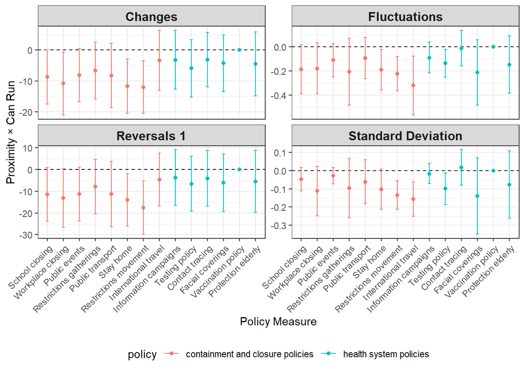

The effect of elections on policy changes (proximity × can-run).

```r
policy_labels <- c(
  "C1_School.closing" = "School closing",
  "C2_Workplace.closing" = "Workplace closing",
  "C3_Cancel.public.events" = "Public events",
  "C4_Restrictions.on.gatherings" = "Restrictions gatherings",
  "C5_Close.public.transport" = "Public transport",
  "C6_Stay.at.home.requirements" = "Stay home",
  "C7_Restrictions.on.internal.movement" = "Restrictions movement",
  "C8_International.travel.controls" = "International travel",
  "H1_Public.information.campaigns" = "Information campaigns",
  "H2_Testing.policy" = "Testing policy",
  "H3_Contact.tracing" = "Contact tracing",
  "H6_Facial.Coverings" = "Facial coverings",
  "H7_Vaccination.policy" = "Vaccination policy",
  "H8_Protection.of.elderly.people" = "Protection elderly"
)

indicator_vars <- setdiff(
  policy_present,
  c("ContainmentHealthIndex", "StringencyIndex", "GovernmentResponseIndex")
)

a1_fig_dat <- map_dfr(indicator_vars, function(variable) {
  map_dfr(c("_sd", "_fluctuation", "_changes", "_reversals1"), function(measure) {
    outcome <- paste0(variable, measure)
    if (!outcome %in% names(oxcgrt)) {
      return(NULL)
    }
    fit <- lm(as.formula(paste(outcome, "~", a1_rhs)), data = oxcgrt)
    sm <- summary(fit)$coef
    tibble(
      outcome = outcome,
      coef_value = unname(sm["electionproximity_yrs_canrun", "Estimate"]),
      std_error = unname(sm["electionproximity_yrs_canrun", "Std. Error"]),
      group = measure
    )
  })
})

fig_pol_updating <- a1_fig_dat |>
  mutate(
    policy = case_when(
      substr(outcome, 1, 1) == "C" ~ "containment and closure policies",
      substr(outcome, 1, 1) == "H" ~ "health system policies",
      TRUE ~ NA_character_
    ),
    outcome = stringr::str_remove_all(outcome, "_sd|_fluctuation|_changes|_reversals1"),
    group = recode(
      group,
      "_sd" = "Standard Deviation",
      "_fluctuation" = "Fluctuations",
      "_changes" = "Changes",
      "_reversals1" = "Reversals 1"
    )
  ) |>
  ggplot(aes(
    x = factor(outcome, levels = names(policy_labels)),
    y = coef_value,
    color = policy
  )) +
  geom_hline(yintercept = 0, linetype = "dashed", color = "black") +
  geom_point() +
  geom_errorbar(
    aes(ymin = coef_value - 1.96 * std_error, ymax = coef_value + 1.96 * std_error),
    width = 0.2
  ) +
  labs(x = "Policy Measure", y = "Proximity × Can Run") +
  facet_wrap(~group, scales = "free_y", ncol = 2) +
  scale_x_discrete(labels = policy_labels) +
  theme_bw() +
  theme(
    strip.text = element_text(size = 12, face = "bold"),
    axis.text.x = element_text(angle = 45, hjust = 1, vjust = 1),
    legend.position = "bottom"
  )

fig_pol_updating
```

```r
ggsave(file.path(fig_dir, "fig_b1_oxcgrt.pdf"), fig_pol_updating, width = 8, height = 5)
```

## 6.4 Summary statistics and priors density

```r
summ_vars <- thirdwave |>
  select(
    age, gender, vaccination_status, vaccine_type, covid_invection,
    trust_government, trust_experts, trust_state_gov, trust_media, trust_stiko,
    political_interest, party_id, prior_pfm, prior_vac_pfm, salience_vac,
    credible, competent, correct, prior_mixed, post_mixed, behav_mixed,
    incumbent_voting, treatment_measurement
  )

summary_table <- summ_vars |>
  mutate(across(everything(), as.numeric)) |>
  summarise(across(
    everything(),
    list(
      N = \(x) sum(!is.na(x)),
      Mean = \(x) mean(x, na.rm = TRUE),
      `Std. Dev.` = \(x) sd(x, na.rm = TRUE),
      Min = \(x) min(x, na.rm = TRUE),
      `Pctl. 25` = \(x) quantile(x, 0.25, na.rm = TRUE),
      `Pctl. 75` = \(x) quantile(x, 0.75, na.rm = TRUE),
      Max = \(x) max(x, na.rm = TRUE)
    ),
    .names = "{.col}__{.fn}"
  )) |>
  pivot_longer(everything(), names_to = c("Variable", "Statistic"), names_sep = "__") |>
  pivot_wider(names_from = "Statistic", values_from = "value") |>
  arrange(Variable)

knitr::kable(
  summary_table,
  digits = 2,
  col.names = c("Variable", "N", "Mean", "Std. Dev.", "Min", "Pctl. 25", "Pctl. 75", "Max"),
  caption = "Summary statistics (aggregates only)."
) |>
  kableExtra::kable_styling(full_width = FALSE)
```

Summary statistics (aggregates only).

| Variable | N | Mean | Std. Dev. | Min | Pctl. 25 | Pctl. 75 | Max |
| --- | --- | --- | --- | --- | --- | --- | --- |
| age | 10456 | 49.79 | 14.50 | 18 | 38.0 | 61.0 | 76.0 |
| behav_mixed | 10456 | 5.44 | 3.86 | 0 | 1.0 | 10.0 | 10.0 |
| competent | 10456 | 0.57 | 0.29 | 0 | 0.4 | 0.8 | 1.1 |
| correct | 10456 | 0.55 | 0.29 | 0 | 0.4 | 0.8 | 1.0 |
| covid_invection | 10456 | 1.97 | 0.18 | 1 | 2.0 | 2.0 | 2.0 |
| credible | 10456 | 0.57 | 0.28 | 0 | 0.4 | 0.8 | 1.0 |
| gender | 10456 | 1.54 | 0.50 | 1 | 1.0 | 2.0 | 3.0 |
| incumbent_voting | 10456 | 1.63 | 0.48 | 1 | 1.0 | 2.0 | 2.0 |
| party_id | 10456 | 5.08 | 2.80 | 1 | 3.0 | 8.0 | 9.0 |
| political_interest | 10456 | 2.00 | 0.86 | 1 | 1.0 | 2.0 | 4.0 |
| post_mixed | 10456 | 5.72 | 3.07 | 0 | 4.0 | 8.0 | 10.0 |
| prior_mixed | 10456 | 6.00 | 2.90 | 0 | 5.0 | 8.0 | 10.0 |
| prior_pfm | 10456 | -0.49 | 2.76 | -5 | -3.0 | 2.0 | 5.0 |
| prior_vac_pfm | 10456 | -0.37 | 2.85 | -5 | -3.0 | 2.0 | 5.0 |
| salience_vac | 10456 | 2.20 | 1.16 | 1 | 1.0 | 3.0 | 5.0 |
| treatment_measurement | 10357 | 5.10 | 2.94 | 0 | 3.0 | 7.0 | 10.0 |
| trust_experts | 10456 | 2.65 | 1.01 | 0 | 2.0 | 3.0 | 4.0 |
| trust_government | 10456 | 1.85 | 1.13 | 0 | 1.0 | 3.0 | 4.0 |
| trust_media | 10456 | 1.67 | 1.03 | 0 | 1.0 | 2.0 | 4.0 |
| trust_state_gov | 10456 | 1.91 | 1.09 | 0 | 1.0 | 3.0 | 4.0 |
| trust_stiko | 10456 | 2.47 | 1.12 | 0 | 2.0 | 3.0 | 4.0 |
| vaccination_status | 10456 | 1.29 | 2.73 | 1 | 1.0 | 1.0 | 99.0 |
| vaccine_type | 8248 | 1.94 | 1.58 | 1 | 1.0 | 3.0 | 6.0 |

```r
writeLines(
  knitr::kable(summary_table, format = "latex", digits = 2, booktabs = TRUE),
  file.path(fig_dir, "tab_d1_summary_stats.tex")
)
```

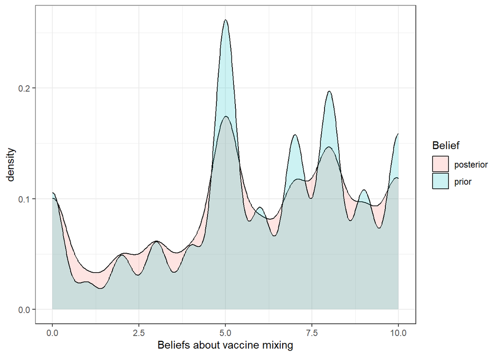

Prior and posterior mixing beliefs (not the Table 2 Belief column).

```r
prior <- tibble(value = thirdwave$prior_mixed, Belief = "prior")
post <- tibble(value = thirdwave$post_mixed, Belief = "posterior")

prior_posterior <- bind_rows(prior, post) |>
  ggplot(aes(value, fill = Belief)) +
  geom_density(alpha = 0.2) +
  xlab("Beliefs about vaccine mixing") +
  theme_bw()

fig_13 <- grid.arrange(prior_posterior, ncol = 1)
```

```r
ggsave(file.path(fig_dir, "fig_d1_priors.pdf"), fig_13, width = 7, height = 4)
```

## 6.5 Manipulation checks

```r
man_science <- lm_robust(I(manipulation_science == 1) ~ science, data = thirdwave)
tab_man_science <- texreg::texreg(
  man_science,
  include.ci = FALSE,
  caption = "Science-video manipulation check",
  label = "tab:man_science",
  stars = c(0.01, 0.05, 0.1),
  custom.coef.map = list("(Intercept)" = "Constant", "science" = "Science video")
)
write(tab_man_science, file = file.path(fig_dir, "tab_e1_man_science.tex"))

man_iv <- lm_robust(treatment_measurement ~ inconsistent, data = thirdwave)
tab_man_iv <- texreg::texreg(
  man_iv,
  include.ci = FALSE,
  caption = "Treatment compliance (perceived inconsistency)",
  label = "TreatmentCompliance",
  stars = c(0.01, 0.05, 0.1),
  custom.coef.map = list(
    "(Intercept)" = "Constant",
    "inconsistent" = "Instrument (inconsistent information)"
  )
)
write(tab_man_iv, file = file.path(fig_dir, "tab_e2_treatment_compliance.tex"))

man_t1_safe <- lm_robust(as.numeric(manipulation_time1) ~ safe_time1, data = thirdwave)
man_t1_unsafe <- lm_robust(as.numeric(manipulation_time1) ~ unsafe_time1, data = thirdwave)
man_t2_safe <- lm_robust(as.numeric(manipulation_time2) ~ safe_time2, data = thirdwave)
man_t2_unsafe <- lm_robust(as.numeric(manipulation_time2) ~ unsafe_time2, data = thirdwave)

tab_man1 <- texreg::texreg(
  list(man_t1_safe, man_t1_unsafe, man_t2_safe, man_t2_unsafe),
  include.ci = FALSE,
  custom.model.names = c("manipulation t1", "manipulation t1", "manipulation t2", "manipulation t2"),
  caption = "Manipulation perceived timing",
  label = "table:timing",
  stars = c(0.001, 0.01, 0.05),
  custom.coef.map = list(
    "safe_time1" = "First message safe",
    "unsafe_time1" = "First message unsafe",
    "safe_time2" = "Second message safe",
    "unsafe_time2" = "Second message unsafe"
  )
)
write(tab_man1, file = file.path(fig_dir, "tab_e3_timing_checks.tex"))
```

```r
show_htmlreg(
  man_science,
  caption = "Science-video manipulation check.",
  names = "Inconsistencies in Science",
  coef_map = list("(Intercept)" = "Constant", "science" = "Science video")
)
```

Science-video manipulation check.

|  | Inconsistencies in Science |
| --- | --- |
| Constant | 0.693*** |
|  | (0.006) |
| Science video | 0.065*** |
|  | (0.009) |
| R<sup>2</sup> | 0.005 |
| Adj. R<sup>2</sup> | 0.005 |
| Num. obs. | 10456 |
| RMSE | 0.445 |

***p < 0.01; **p < 0.05; *p < 0.1

```r
show_htmlreg(
  man_iv,
  caption = "First stage: perceived inconsistency.",
  names = "Treatment Measurement",
  coef_map = list(
    "(Intercept)" = "Constant",
    "inconsistent" = "Instrument (inconsistent information)"
  )
)
```

First stage: perceived inconsistency.

|  | Treatment Measurement |
| --- | --- |
| Constant | 4.695*** |
|  | (0.040) |
| Instrument (inconsistent information) | 0.809*** |
|  | (0.057) |
| R<sup>2</sup> | 0.019 |
| Adj. R<sup>2</sup> | 0.019 |
| Num. obs. | 10357 |
| RMSE | 2.909 |

***p < 0.01; **p < 0.05; *p < 0.1

```r
show_htmlreg(
  list(man_t1_safe, man_t1_unsafe, man_t2_safe, man_t2_unsafe),
  caption = "Manipulation perceived timing.",
  names = c("manipulation t1", "manipulation t1", "manipulation t2", "manipulation t2"),
  coef_map = list(
    "safe_time1" = "safe_time1",
    "unsafe_time1" = "unsafe_time1",
    "safe_time2" = "safe_time2",
    "unsafe_time2" = "unsafe_time2"
  )
)
```

Manipulation perceived timing.

|  | manipulation t1 | manipulation t1 | manipulation t2 | manipulation t2 |
| --- | --- | --- | --- | --- |
| safe_time1 | 1.742*** |  |  |  |
|  | (0.038) |  |  |  |
| unsafe_time1 |  | -1.742*** |  |  |
|  |  | (0.038) |  |  |
| safe_time2 |  |  | 1.596*** |  |
|  |  |  | (0.039) |  |
| unsafe_time2 |  |  |  | -1.596*** |
|  |  |  |  | (0.039) |
| R<sup>2</sup> | 0.166 | 0.166 | 0.141 | 0.141 |
| Adj. R<sup>2</sup> | 0.166 | 0.166 | 0.141 | 0.141 |
| Num. obs. | 10456 | 10456 | 10456 | 10456 |
| RMSE | 1.952 | 1.952 | 1.968 | 1.968 |

***p < 0.01; **p < 0.05; *p < 0.1

## 6.6 Appendix. Order-conditional coefficient grid

The order-conditional coefficient grid is from the **same** pooled four-way fits as Table 2. Colors are first message safe versus first message unsafe. Other treatments at their means (0 after demeaning). These are $\beta_2+\beta_r$ and $-\beta_2+\beta_r$, not two penalties. Subsample fits below are **not** the source of this figure.

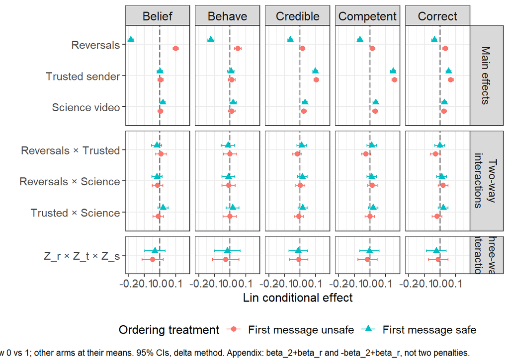

Lin conditional effects by first-message order, from the pooled four-way saturated model (Table 2). Appendix.

```r
order_dat <- map2_dfr(saturated, outcome_labels, function(fit, lab) {
  map_dfr(c(0, 1), function(o) {
    d_o <- o - mean_ord
    map_dfr(seq_len(nrow(effect_defs)), function(i) {
      sp <- effect_defs[i, ]
      lincom_fit(fit, pairs_at_order(sp$base, d_o)) |>
        mutate(
          outcome = lab,
          row_type = sp$row_type,
          effect = sp$effect,
          order = if_else(o == 1, "First message safe", "First message unsafe")
        )
    })
  })
}) |>
  mutate(
    outcome = factor(outcome, outcome_labels),
    order = factor(order, c("First message unsafe", "First message safe"))
  )

fig_order <- plot_cond_grid(
  order_dat,
  color_var = "order",
  color_lab = "Ordering treatment",
  caption = "From Table 2: Y ~ inconsistent x trusted x science x safe_time1, treatments demeaned. Conditional effects evaluate demeaned safe_time1 at raw 0 vs 1; other arms at their means. 95% CIs, delta method. Appendix: beta_2+beta_r and -beta_2+beta_r, not two penalties."
)

fig_order
```

```r
ggsave(file.path(fig_dir, "fig_3_order_effects.pdf"), fig_order, width = 13, height = 9.2)
```

## 6.7 Appendix. Mixed-message saturation

Lin-demeaned `mixed_1 * mixed_2 * science * trusted`. Same four message cells as Table 2 under a 1–1 recoding (`mixed_1` = `safe_time1` $=Z_1$, `mixed_2` = `safe_time2` $=Z_2$). Treatments stay 0/1 in the frame and are demeaned at fit. No hidden rows. The `mixed_1:mixed_2` coefficient is $-2\beta_r$. Appendix exhibit; same model as Table 2 with a different parameterization ($Z_1\times Z_2$ in place of $Z_r\times Z_1$).

```r
saturated_mixed <- fit_saturated_list(
  thirdwave,
  rhs = mixed_rhs,
  vars = mixed_vars
)

tab_mixed <- write_texreg(
  saturated_mixed,
  file = file.path(fig_dir, "tab_3_mixed_messages.tex"),
  caption = "Fully saturated model in the $Z_1$, $Z_2$ parameterization. Treatments demeaned (Lin 2013); reported main effects are averages. Outcomes on $[0,1]$. Belief = conviction of the second message; Behave = willingness to follow the second message.",
  label = "table:mixed",
  coef_map = mixed.coef.map
)
```

```r
show_htmlreg(
  saturated_mixed,
  caption = "Appendix. Fully saturated four-way model, $Z_1 \\times Z_2 \\times Z_s \\times Z_t$. Same model as Table 2 with a different parameterization. Treatments demeaned (Lin 2013); main effects are averages. Belief / Behave are recoded agreement with the second recommendation.",
  coef_map = mixed.coef.map
)
```

Appendix. Fully saturated four-way model, $Z_1 \times Z_2 \times Z_s \times Z_t$. Same model as Table 2 with a different parameterization. Treatments demeaned (Lin 2013); main effects are averages. Belief / Behave are recoded agreement with the second recommendation.

|  | Belief | Behave | Credible | Competent | Correct |
| --- | --- | --- | --- | --- | --- |
| First message safe ($Z_1$) | 0.003 | 0.012 | 0.034*** | 0.030*** | 0.028*** |
|  | (0.006) | (0.008) | (0.005) | (0.006) | (0.006) |
| Second message safe ($Z_2$) | 0.144*** | 0.087*** | 0.040*** | 0.040*** | 0.035*** |
|  | (0.006) | (0.008) | (0.005) | (0.005) | (0.006) |
| Trusted sender ($Z_t$) | 0.002 | 0.009 | 0.101*** | 0.151*** | 0.061*** |
|  | (0.006) | (0.008) | (0.005) | (0.006) | (0.006) |
| Science video ($Z_s$) | 0.010* | 0.015** | 0.028*** | 0.034*** | 0.026*** |
|  | (0.006) | (0.008) | (0.005) | (0.006) | (0.006) |
| First $\times$ Second safe ($-2\beta_r$) | 0.085*** | 0.074*** | 0.046*** | 0.050*** | 0.004 |
|  | (0.012) | (0.015) | (0.011) | (0.011) | (0.011) |
| First safe $\times$ Trusted | -0.006 | -0.006 | -0.007 | -0.010 | -0.014 |
|  | (0.012) | (0.015) | (0.011) | (0.011) | (0.011) |
| Second safe $\times$ Trusted | 0.014 | 0.007 | -0.014 | -0.018* | -0.014 |
|  | (0.012) | (0.015) | (0.011) | (0.011) | (0.011) |
| First safe $\times$ Science | 0.015 | 0.008 | 0.006 | 0.003 | 0.001 |
|  | (0.012) | (0.015) | (0.011) | (0.011) | (0.011) |
| Second safe $\times$ Science | 0.002 | 0.001 | -0.006 | 0.002 | 0.004 |
|  | (0.012) | (0.015) | (0.011) | (0.011) | (0.011) |
| Science $\times$ Trusted | 0.004 | 0.008 | 0.004 | 0.010 | 0.000 |
|  | (0.012) | (0.015) | (0.011) | (0.011) | (0.011) |
| $Z_1 \times Z_2 \times Z_t$ | 0.014 | 0.014 | 0.007 | 0.016 | 0.031 |
|  | (0.024) | (0.030) | (0.021) | (0.022) | (0.023) |
| $Z_1 \times Z_2 \times Z_s$ | 0.035 | 0.018 | -0.017 | -0.025 | -0.030 |
|  | (0.024) | (0.030) | (0.021) | (0.022) | (0.023) |
| $Z_1 \times Z_s \times Z_t$ | 0.031 | 0.019 | 0.024 | 0.020 | 0.039* |
|  | (0.024) | (0.030) | (0.021) | (0.022) | (0.023) |
| $Z_2 \times Z_s \times Z_t$ | -0.007 | -0.005 | 0.002 | -0.006 | 0.006 |
|  | (0.024) | (0.030) | (0.021) | (0.022) | (0.023) |
| $Z_1 \times Z_2 \times Z_s \times Z_t$ | 0.081* | 0.044 | 0.020 | 0.020 | 0.035 |
|  | (0.048) | (0.060) | (0.043) | (0.044) | (0.045) |
| R<sup>2</sup> | 0.058 | 0.016 | 0.046 | 0.080 | 0.020 |
| Adj. R<sup>2</sup> | 0.057 | 0.014 | 0.044 | 0.079 | 0.019 |
| Num. obs. | 10456 | 10456 | 10456 | 10456 | 10456 |
| RMSE | 0.306 | 0.385 | 0.274 | 0.281 | 0.289 |

***p < 0.01; **p < 0.05; *p < 0.1

## 6.8 Extra saturated tables (appendix; not used for the order graphs)

High priors use `prior_mixed > 6.6`.

```r
sat_0 <- fit_saturated_list(
  filter(thirdwave, safe_time1 == 0),
  rhs = "inconsistent * trusted * science"
)
sat_1 <- fit_saturated_list(
  filter(thirdwave, safe_time1 == 1),
  rhs = "inconsistent * trusted * science"
)

write_texreg(
  sat_0,
  file = file.path(fig_dir, "tab_g1_order_unsafe.tex"),
  caption = "Fully saturated model | first message against mixing (subsample; not the order figure)",
  label = "table:saturated_0",
  coef_map = full.coef.map[names(full.coef.map) %in% c(
    "inconsistent", "trusted", "science",
    "inconsistent:trusted", "inconsistent:science", "trusted:science",
    "inconsistent:trusted:science"
  )]
)
write_texreg(
  sat_1,
  file = file.path(fig_dir, "tab_g2_order_safe.tex"),
  caption = "Fully saturated model | first message supports mixing (subsample; not the order figure)",
  label = "table:saturated_1",
  coef_map = full.coef.map[names(full.coef.map) %in% c(
    "inconsistent", "trusted", "science",
    "inconsistent:trusted", "inconsistent:science", "trusted:science",
    "inconsistent:trusted:science"
  )]
)

dat_low <- filter(thirdwave, prior_mixed < prior_low)
dat_med <- filter(thirdwave, prior_mixed > prior_low & prior_mixed < prior_high)
dat_high <- filter(thirdwave, prior_mixed > prior_high)

c(
  low = nrow(dat_low),
  med = nrow(dat_med),
  high = nrow(dat_high)
)

sat_low <- fit_saturated_list(dat_low)
sat_med <- fit_saturated_list(dat_med)
sat_high <- fit_saturated_list(dat_high)

# The cuts split the 0-10 scale into equal thirds, not the sample into
# terciles, so the groups are unequal. Each caption carries its own n.
prior_n_lab <- function(d) {
  sprintf(
    "$n = %s$, %.1f\\%% of the sample",
    formatC(nrow(d), big.mark = ",", format = "d"),
    100 * nrow(d) / nrow(thirdwave)
  )
}

write_texreg(
  sat_low,
  file = file.path(fig_dir, "tab_g5_low_priors.tex"),
  caption = paste0(
    "Fully saturated model, low priors (prior on mixing $<$ 3.3; ",
    prior_n_lab(dat_low), ")"
  ),
  label = "tab:saturated_low_priors"
)
write_texreg(
  sat_med,
  file = file.path(fig_dir, "tab_g4_med_priors.tex"),
  caption = paste0(
    "Fully saturated model, middling priors (3.3 $<$ prior on mixing $<$ 6.6; ",
    prior_n_lab(dat_med), ")"
  ),
  label = "tab:saturated_med_priors"
)
write_texreg(
  sat_high,
  file = file.path(fig_dir, "tab_g3_high_priors.tex"),
  caption = paste0(
    "Fully saturated model, high priors (prior on mixing $>$ 6.6; ",
    prior_n_lab(dat_high), ")"
  ),
  label = "tab:saturated_high_priors"
)
```

```r
threeway_coef_map <- full.coef.map[names(full.coef.map) %in% c(
  "inconsistent", "trusted", "science",
  "inconsistent:trusted", "inconsistent:science", "trusted:science",
  "inconsistent:trusted:science"
)]

show_htmlreg(
  sat_0,
  caption = "Fully saturated model | first message against mixing (subsample; not the order figure).",
  coef_map = threeway_coef_map
)
```

Fully saturated model | first message against mixing (subsample; not the order figure).

|  | Belief | Behave | Credible | Competent | Correct |
| --- | --- | --- | --- | --- | --- |
| Reversals ($Z_r$) | 0.102*** | 0.050*** | 0.017** | 0.016** | 0.033*** |
|  | (0.009) | (0.011) | (0.008) | (0.008) | (0.008) |
| Reversals $\times$ Science | -0.016 | -0.008 | 0.003 | 0.015 | 0.019 |
|  | (0.017) | (0.022) | (0.015) | (0.015) | (0.016) |
| Reversals $\times$ Trusted | 0.007 | 0.000 | -0.017 | -0.026* | -0.030* |
|  | (0.017) | (0.022) | (0.015) | (0.015) | (0.016) |
| Trusted sender ($Z_t$) | 0.005 | 0.012 | 0.104*** | 0.156*** | 0.069*** |
|  | (0.009) | (0.011) | (0.008) | (0.008) | (0.008) |
| Science video ($Z_s$) | 0.003 | 0.011 | 0.025*** | 0.033*** | 0.025*** |
|  | (0.009) | (0.011) | (0.008) | (0.008) | (0.008) |
| Trusted $\times$ Science | -0.011 | -0.002 | -0.008 | -0.000 | -0.019 |
|  | (0.017) | (0.022) | (0.015) | (0.015) | (0.016) |
| $Z_r \times Z_t \times Z_s$ | -0.048 | -0.027 | -0.008 | -0.016 | -0.012 |
|  | (0.034) | (0.043) | (0.030) | (0.031) | (0.032) |
| R<sup>2</sup> | 0.027 | 0.005 | 0.038 | 0.077 | 0.020 |
| Adj. R<sup>2</sup> | 0.025 | 0.003 | 0.037 | 0.075 | 0.019 |
| Num. obs. | 5230 | 5230 | 5230 | 5230 | 5230 |
| RMSE | 0.311 | 0.389 | 0.274 | 0.280 | 0.289 |

***p < 0.01; **p < 0.05; *p < 0.1

```r
show_htmlreg(
  sat_1,
  caption = "Fully saturated model | first message supports mixing (subsample; not the order figure).",
  coef_map = threeway_coef_map
)
```

Fully saturated model | first message supports mixing (subsample; not the order figure).

|  | Belief | Behave | Credible | Competent | Correct |
| --- | --- | --- | --- | --- | --- |
| Reversals ($Z_r$) | -0.187*** | -0.124*** | -0.063*** | -0.065*** | -0.037*** |
|  | (0.008) | (0.011) | (0.008) | (0.008) | (0.008) |
| Reversals $\times$ Science | -0.019 | -0.010 | 0.015 | 0.010 | 0.011 |
|  | (0.017) | (0.021) | (0.015) | (0.016) | (0.016) |
| Reversals $\times$ Trusted | -0.020 | -0.014 | 0.010 | 0.010 | -0.001 |
|  | (0.017) | (0.021) | (0.015) | (0.016) | (0.016) |
| Trusted sender ($Z_t$) | -0.000 | 0.006 | 0.097*** | 0.147*** | 0.054*** |
|  | (0.008) | (0.011) | (0.008) | (0.008) | (0.008) |
| Science video ($Z_s$) | 0.018** | 0.020* | 0.031*** | 0.036*** | 0.027*** |
|  | (0.008) | (0.011) | (0.008) | (0.008) | (0.008) |
| Trusted $\times$ Science | 0.020 | 0.017 | 0.016 | 0.020 | 0.020 |
|  | (0.017) | (0.021) | (0.015) | (0.016) | (0.016) |
| $Z_r \times Z_t \times Z_s$ | -0.033 | -0.017 | -0.012 | -0.004 | -0.024 |
|  | (0.033) | (0.042) | (0.030) | (0.031) | (0.032) |
| R<sup>2</sup> | 0.090 | 0.027 | 0.046 | 0.079 | 0.015 |
| Adj. R<sup>2</sup> | 0.088 | 0.025 | 0.045 | 0.077 | 0.014 |
| Num. obs. | 5226 | 5226 | 5226 | 5226 | 5226 |
| RMSE | 0.301 | 0.382 | 0.274 | 0.282 | 0.289 |

***p < 0.01; **p < 0.05; *p < 0.1

```r
show_htmlreg(
  sat_low,
  caption = "Fully saturated model, low priors (prior on mixing < 3.3)."
)
```

Fully saturated model, low priors (prior on mixing < 3.3).

|  | Belief | Behave | Credible | Competent | Correct |
| --- | --- | --- | --- | --- | --- |
| Reversals ($Z_r$) | -0.039*** | -0.026** | -0.048*** | -0.047*** | -0.029** |
|  | (0.010) | (0.010) | (0.012) | (0.013) | (0.012) |
| Reversals $\times$ Science | 0.002 | 0.007 | 0.006 | 0.002 | 0.002 |
|  | (0.020) | (0.021) | (0.025) | (0.025) | (0.025) |
| Reversals $\times$ Trusted | 0.015 | 0.006 | -0.014 | -0.022 | 0.005 |
|  | (0.020) | (0.021) | (0.025) | (0.025) | (0.025) |
| First message safe ($Z_1$) | 0.024** | 0.037*** | 0.015 | 0.013 | 0.019 |
|  | (0.010) | (0.010) | (0.012) | (0.013) | (0.012) |
| Trusted sender ($Z_t$) | 0.011 | 0.007 | 0.129*** | 0.165*** | 0.101*** |
|  | (0.010) | (0.010) | (0.012) | (0.013) | (0.012) |
| Science video ($Z_s$) | 0.007 | 0.021** | 0.050*** | 0.055*** | 0.038*** |
|  | (0.010) | (0.010) | (0.012) | (0.013) | (0.012) |
| Trusted $\times$ Science | 0.002 | 0.044** | 0.024 | 0.028 | 0.039 |
|  | (0.020) | (0.021) | (0.025) | (0.025) | (0.024) |
| Reversals $\times$ First safe | 1.206*** | 1.491*** | 0.041* | 0.035 | 0.099*** |
|  | (0.020) | (0.021) | (0.025) | (0.025) | (0.025) |
| Trusted $\times$ First safe | -0.008 | 0.002 | -0.010 | -0.020 | -0.035 |
|  | (0.020) | (0.021) | (0.025) | (0.025) | (0.024) |
| Science $\times$ First safe | 0.030 | 0.051** | -0.042* | -0.038 | -0.030 |
|  | (0.020) | (0.021) | (0.025) | (0.025) | (0.024) |
| $Z_r \times Z_t \times Z_s$ | -0.058 | -0.045 | -0.048 | -0.095* | -0.072 |
|  | (0.040) | (0.041) | (0.050) | (0.050) | (0.049) |
| $Z_r \times Z_t \times Z_1$ | -0.132*** | -0.062 | 0.010 | 0.016 | -0.014 |
|  | (0.040) | (0.041) | (0.050) | (0.050) | (0.049) |
| $Z_r \times Z_s \times Z_1$ | -0.081** | -0.058 | 0.087* | 0.038 | 0.049 |
|  | (0.040) | (0.041) | (0.050) | (0.050) | (0.049) |
| $Z_t \times Z_s \times Z_1$ | 0.070* | 0.065 | 0.048 | 0.024 | 0.082* |
|  | (0.040) | (0.041) | (0.050) | (0.050) | (0.049) |
| $Z_r \times Z_t \times Z_s \times Z_1$ | 0.076 | -0.021 | -0.041 | 0.008 | -0.077 |
|  | (0.080) | (0.083) | (0.100) | (0.100) | (0.098) |
| R<sup>2</sup> | 0.650 | 0.725 | 0.069 | 0.098 | 0.053 |
| Adj. R<sup>2</sup> | 0.647 | 0.723 | 0.062 | 0.091 | 0.046 |
| Num. obs. | 1978 | 1978 | 1978 | 1978 | 1978 |
| RMSE | 0.223 | 0.231 | 0.278 | 0.279 | 0.273 |

***p < 0.01; **p < 0.05; *p < 0.1

```r
show_htmlreg(
  sat_med,
  caption = "Fully saturated model, middling priors (3.3 < prior on mixing < 6.6)."
)
```

Fully saturated model, middling priors (3.3 < prior on mixing < 6.6).

|  | Belief | Behave | Credible | Competent | Correct |
| --- | --- | --- | --- | --- | --- |
| Reversals ($Z_r$) | -0.053*** | -0.055*** | -0.030*** | -0.030*** | -0.015* |
|  | (0.007) | (0.011) | (0.008) | (0.008) | (0.008) |
| Reversals $\times$ Science | -0.018 | -0.019 | 0.007 | 0.020 | 0.026 |
|  | (0.015) | (0.023) | (0.016) | (0.016) | (0.017) |
| Reversals $\times$ Trusted | -0.008 | 0.002 | -0.009 | -0.010 | -0.015 |
|  | (0.015) | (0.023) | (0.016) | (0.016) | (0.017) |
| First message safe ($Z_1$) | -0.001 | 0.001 | 0.014* | 0.017** | 0.008 |
|  | (0.007) | (0.011) | (0.008) | (0.008) | (0.008) |
| Trusted sender ($Z_t$) | 0.016** | 0.030*** | 0.102*** | 0.147*** | 0.069*** |
|  | (0.007) | (0.011) | (0.008) | (0.008) | (0.008) |
| Science video ($Z_s$) | 0.016** | 0.011 | 0.033*** | 0.038*** | 0.036*** |
|  | (0.007) | (0.011) | (0.008) | (0.008) | (0.008) |
| Trusted $\times$ Science | -0.000 | 0.019 | -0.021 | -0.020 | -0.036** |
|  | (0.015) | (0.023) | (0.016) | (0.016) | (0.017) |
| Reversals $\times$ First safe | 0.010 | 0.218*** | -0.059*** | -0.070*** | -0.063*** |
|  | (0.015) | (0.023) | (0.016) | (0.016) | (0.017) |
| Trusted $\times$ First safe | -0.004 | 0.001 | -0.025 | -0.030* | -0.022 |
|  | (0.015) | (0.023) | (0.016) | (0.016) | (0.017) |
| Science $\times$ First safe | -0.005 | -0.015 | 0.008 | 0.014 | 0.024 |
|  | (0.015) | (0.023) | (0.016) | (0.016) | (0.017) |
| $Z_r \times Z_t \times Z_s$ | -0.061** | -0.010 | 0.009 | -0.007 | -0.026 |
|  | (0.029) | (0.045) | (0.032) | (0.033) | (0.034) |
| $Z_r \times Z_t \times Z_1$ | -0.038 | -0.014 | -0.012 | -0.005 | -0.013 |
|  | (0.030) | (0.045) | (0.032) | (0.033) | (0.034) |
| $Z_r \times Z_s \times Z_1$ | 0.000 | -0.013 | -0.007 | -0.018 | -0.062* |
|  | (0.029) | (0.045) | (0.032) | (0.033) | (0.034) |
| $Z_t \times Z_s \times Z_1$ | 0.003 | -0.020 | 0.052 | 0.032 | 0.046 |
|  | (0.029) | (0.045) | (0.032) | (0.033) | (0.034) |
| $Z_r \times Z_t \times Z_s \times Z_1$ | 0.010 | 0.082 | -0.008 | 0.014 | -0.026 |
|  | (0.059) | (0.090) | (0.064) | (0.065) | (0.067) |
| R<sup>2</sup> | 0.020 | 0.037 | 0.061 | 0.105 | 0.035 |
| Adj. R<sup>2</sup> | 0.016 | 0.033 | 0.057 | 0.101 | 0.030 |
| Num. obs. | 3373 | 3373 | 3373 | 3373 | 3373 |
| RMSE | 0.214 | 0.327 | 0.232 | 0.235 | 0.243 |

***p < 0.01; **p < 0.05; *p < 0.1

```r
show_htmlreg(
  sat_high,
  caption = "Fully saturated model, high priors (prior on mixing > 6.6)."
)
```

Fully saturated model, high priors (prior on mixing > 6.6).

|  | Belief | Behave | Credible | Competent | Correct |
| --- | --- | --- | --- | --- | --- |
| Reversals ($Z_r$) | -0.037*** | -0.029*** | -0.003 | -0.007 | 0.023*** |
|  | (0.006) | (0.008) | (0.006) | (0.007) | (0.007) |
| Reversals $\times$ Science | -0.001 | 0.017 | 0.020 | 0.020 | 0.023* |
|  | (0.012) | (0.017) | (0.013) | (0.014) | (0.014) |
| Reversals $\times$ Trusted | -0.007 | -0.011 | 0.007 | 0.003 | -0.020 |
|  | (0.012) | (0.017) | (0.013) | (0.014) | (0.014) |
| First message safe ($Z_1$) | -0.000 | 0.012 | 0.061*** | 0.051*** | 0.053*** |
|  | (0.006) | (0.008) | (0.006) | (0.007) | (0.007) |
| Trusted sender ($Z_t$) | 0.002 | 0.010 | 0.097*** | 0.157*** | 0.050*** |
|  | (0.006) | (0.008) | (0.006) | (0.007) | (0.007) |
| Science video ($Z_s$) | 0.003 | 0.009 | 0.025*** | 0.033*** | 0.024*** |
|  | (0.006) | (0.008) | (0.006) | (0.007) | (0.007) |
| Trusted $\times$ Science | 0.015 | -0.008 | 0.004 | 0.013 | -0.001 |
|  | (0.012) | (0.017) | (0.013) | (0.014) | (0.014) |
| Reversals $\times$ First safe | -1.067*** | -1.081*** | -0.136*** | -0.129*** | -0.137*** |
|  | (0.012) | (0.017) | (0.013) | (0.014) | (0.014) |
| Trusted $\times$ First safe | -0.016 | -0.025 | 0.000 | 0.003 | -0.007 |
|  | (0.012) | (0.017) | (0.013) | (0.014) | (0.014) |
| Science $\times$ First safe | 0.015 | 0.000 | 0.012 | -0.002 | -0.014 |
|  | (0.012) | (0.017) | (0.013) | (0.014) | (0.014) |
| $Z_r \times Z_t \times Z_s$ | 0.013 | 0.018 | 0.026 | 0.055** | 0.045 |
|  | (0.024) | (0.033) | (0.026) | (0.027) | (0.027) |
| $Z_r \times Z_t \times Z_1$ | -0.021 | -0.040 | 0.035 | 0.045* | 0.041 |
|  | (0.024) | (0.033) | (0.026) | (0.027) | (0.027) |
| $Z_r \times Z_s \times Z_1$ | -0.040* | -0.047 | 0.001 | -0.005 | 0.011 |
|  | (0.024) | (0.033) | (0.026) | (0.027) | (0.027) |
| $Z_t \times Z_s \times Z_1$ | -0.022 | -0.042 | -0.026 | -0.012 | -0.006 |
|  | (0.024) | (0.033) | (0.026) | (0.027) | (0.027) |
| $Z_r \times Z_t \times Z_s \times Z_1$ | 0.058 | 0.037 | 0.005 | 0.008 | 0.012 |
|  | (0.048) | (0.066) | (0.051) | (0.055) | (0.055) |
| R<sup>2</sup> | 0.607 | 0.456 | 0.082 | 0.121 | 0.046 |
| Adj. R<sup>2</sup> | 0.606 | 0.454 | 0.079 | 0.118 | 0.044 |
| Num. obs. | 5105 | 5105 | 5105 | 5105 | 5105 |
| RMSE | 0.216 | 0.296 | 0.228 | 0.244 | 0.243 |

***p < 0.01; **p < 0.05; *p < 0.1

## 6.9 Appendix. Conditional effects by prior group

Same skeleton as the order plot. Colors are low / mid / high priors (cuts 3.3 / 6.6), dodged low–middling–high (not alphabetical), low at the top of each cluster. **One pooled model** per outcome: four treatments interacted with prior group. Effects at the mean of the other treatments (including order). Not three subsample fits. Appendix exhibit; main-text prior claims come from the $\beta_1$, $\beta_2$, $\beta_r$ figure. The `saturated_prior` *fit* is in the main-text abc chunk.

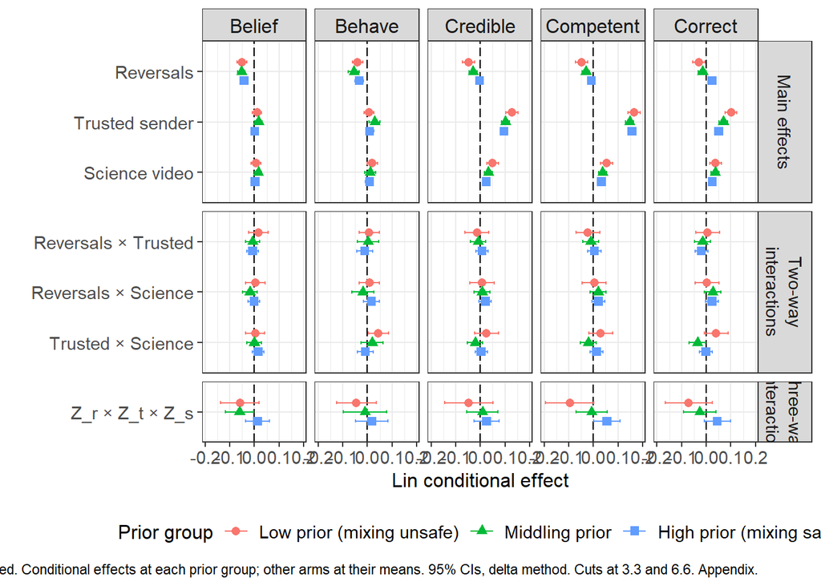

Lin conditional effects by prior group, from a pooled four-treatment × prior-group model. Appendix.

```r
# Reuse the pooled four-treatment × prior fit from the beta_1/beta_2/beta_r figure when present.
if (!exists("saturated_prior")) {
  dat_prior <- thirdwave |>
    filter(!is.na(prior_g))
  # Reference = low. Dummy names from R factor coding after demeaning treatments only.
  prior_rhs <- "inconsistent * trusted * science * safe_time1 * prior_g"
  saturated_prior <- lapply(outcomes, function(y) {
    d <- with_demeaned_treatments(dat_prior, treatment_vars)
    lm_robust(as.formula(paste(y, "~", prior_rhs)), data = d)
  })
  prior_levels <- levels(dat_prior$prior_g)
  prior_mains <- grep("^prior_g", names(coef(saturated_prior[[1]])), value = TRUE)
  prior_mains <- prior_mains[!grepl(":", prior_mains)]
  prior_dummies <- setNames(rep(NA_character_, length(prior_levels)), prior_levels)
  for (nm in prior_mains) {
    lev <- sub("^prior_g", "", nm)
    if (lev %in% names(prior_dummies)) prior_dummies[[lev]] <- nm
  }
}

prior_dat <- map2_dfr(saturated_prior, outcome_labels, function(fit, lab) {
  map_dfr(names(prior_dummies), function(g) {
    dum <- prior_dummies[[g]]
    map_dfr(seq_len(nrow(effect_defs)), function(i) {
      sp <- effect_defs[i, ]
      lincom_fit(fit, pairs_at_group(sp$base, dum)) |>
        mutate(
          outcome = lab,
          row_type = sp$row_type,
          effect = sp$effect,
          prior = prior_lab_long[[g]]
        )
    })
  })
}) |>
  mutate(
    outcome = factor(outcome, outcome_labels),
    prior = factor(prior, unname(prior_lab_long))
  )

# Factor: low, middling, high (not alphabetical). dodge_reverse puts low at the top.
fig_prior <- plot_cond_grid(
  prior_dat,
  color_var = "prior",
  color_lab = "Prior group",
  dodge_reverse = TRUE,
  caption = "Pooled: Y ~ inconsistent × trusted × science × safe_time1 × prior group, treatments demeaned. Conditional effects at each prior group; other arms at their means. 95% CIs, delta method. Cuts at 3.3 and 6.6. Appendix.",
  extra = function(p, d) {
    p +
      scale_color_discrete(breaks = unname(prior_lab_long)) +
      scale_shape_discrete(breaks = unname(prior_lab_long))
  }
)

fig_prior
```

```r
ggsave(file.path(fig_dir, "fig_6_prior_effects.pdf"), fig_prior, width = 13, height = 9.2)
```

```r
# Confirm dummy names exist in the first prior-interacted fit (coefficients only).
cat("Prior-interacted terms containing 'prior_g':\n")
```

Prior-interacted terms containing ‘prior_g’:

```r
cat(paste(grep("prior_g", names(coef(saturated_prior[[1]])), value = TRUE), collapse = "\n"))
```

prior_gmid prior_ghigh inconsistent:prior_gmid inconsistent:prior_ghigh trusted:prior_gmid trusted:prior_ghigh science:prior_gmid science:prior_ghigh safe_time1:prior_gmid safe_time1:prior_ghigh inconsistent:trusted:prior_gmid inconsistent:trusted:prior_ghigh inconsistent:science:prior_gmid inconsistent:science:prior_ghigh trusted:science:prior_gmid trusted:science:prior_ghigh inconsistent:safe_time1:prior_gmid inconsistent:safe_time1:prior_ghigh trusted:safe_time1:prior_gmid trusted:safe_time1:prior_ghigh science:safe_time1:prior_gmid science:safe_time1:prior_ghigh inconsistent:trusted:science:prior_gmid inconsistent:trusted:science:prior_ghigh inconsistent:trusted:safe_time1:prior_gmid inconsistent:trusted:safe_time1:prior_ghigh inconsistent:science:safe_time1:prior_gmid inconsistent:science:safe_time1:prior_ghigh trusted:science:safe_time1:prior_gmid trusted:science:safe_time1:prior_ghigh inconsistent:trusted:science:safe_time1:prior_gmid inconsistent:trusted:science:safe_time1:prior_ghigh

```r
cat("\n\nprior factor / legend order: ", paste(unname(prior_lab_long), collapse = " | "), "\n", sep = "")
```

prior factor / legend order: Low prior (mixing unsafe) | Middling prior | High prior (mixing safe)

```r
eb_p <- ggplot_build(fig_prior)$data[[2]]
one_p <- eb_p[as.integer(eb_p$PANEL) == 1, ]
one_p <- one_p[one_p$y > max(one_p$y) - 0.7, ]
one_p <- one_p[order(-one_p$y), ]
src_p <- dplyr::filter(prior_dat, outcome == "Belief", effect == "Reversals")
dodge_p <- as.character(src_p$prior[match(round(one_p$x, 8), round(src_p$estimate, 8))])
cat("prior visual top-to-bottom (Belief, Reversals): ", paste(dodge_p, collapse = " | "), "\n", sep = "")
```

prior visual top-to-bottom (Belief, Reversals): Low prior (mixing unsafe) | Middling prior | High prior (mixing safe)

## 6.10 Party plot

Same skeleton as the order and prior graphs. Colors = parties. **One pooled model** per outcome: four treatments interacted with party. CDU and CSU combined before the interaction. Non-identifiers (`keiner Partei` / none) and Other / rare parties dropped, not plotted. PAP exploratory. Appendix (after the order grid).

```r
party_keep <- c(
  "CDU/CSU",
  "SPD",
  "Bündnis 90/Die Grünen",
  "FDP",
  "Die Linke",
  "AfD"
)
party_drop <- c(
  "keiner Partei", "None", "no party", "No party",
  "Other", "Andere Partei, und zwar:"
)

dat_party <- thirdwave |>
  filter(!is.na(party_f), party_f != "") |>
  filter(!(party_f %in% party_drop)) |>
  mutate(party_g = factor(party_f, levels = party_keep)) |>
  filter(!is.na(party_g))

knitr::kable(
  dat_party |>
    count(party_g) |>
    mutate(share = n / sum(n)),
  digits = 3,
  caption = "Party analysis sample (CDU/CSU combined; keiner Partei and Other omitted). Counts only."
)
```

Party analysis sample (CDU/CSU combined; keiner Partei and Other omitted). Counts only.

| party_g | n | share |
| --- | --- | --- |
| CDU/CSU | 2221 | 0.285 |
| SPD | 1422 | 0.182 |
| Bündnis 90/Die Grünen | 1631 | 0.209 |
| FDP | 772 | 0.099 |
| Die Linke | 900 | 0.115 |
| AfD | 853 | 0.109 |

Lin conditional effects by party (exploratory). Pooled four-treatment × party model. CDU/CSU combined; keiner Partei and Other omitted.

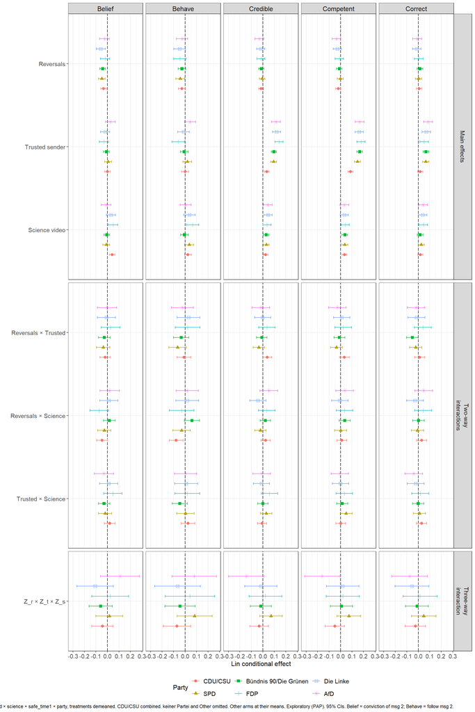

Lin conditional effects by party (exploratory). Pooled four-treatment × party model. CDU/CSU combined; keiner Partei and Other omitted.

```r
party_levels <- levels(dat_party$party_g)
party_dummies <- setNames(
  c(NA_character_, paste0("party_g", party_levels[-1])),
  party_levels
)

party_rhs <- "inconsistent * trusted * science * safe_time1 * party_g"

saturated_party <- lapply(outcomes, function(y) {
  d <- with_demeaned_treatments(dat_party, treatment_vars)
  lm_robust(as.formula(paste(y, "~", party_rhs)), data = d)
})

party_dat <- map2_dfr(saturated_party, outcome_labels, function(fit, lab) {
  map_dfr(names(party_dummies), function(g) {
    dum <- party_dummies[[g]]
    map_dfr(seq_len(nrow(effect_defs)), function(i) {
      sp <- effect_defs[i, ]
      lincom_fit(fit, pairs_at_group(sp$base, dum)) |>
        mutate(
          outcome = lab,
          row_type = sp$row_type,
          effect = sp$effect,
          party = g
        )
    })
  })
}) |>
  mutate(
    outcome = factor(outcome, outcome_labels),
    party = factor(party, party_levels)
  )

fig_party <- plot_cond_grid(
  party_dat,
  color_var = "party",
  color_lab = "Party",
  dodge = 0.72,
  caption = "Pooled: Y ~ inconsistent × trusted × science × safe_time1 × party, treatments demeaned. CDU/CSU combined. keiner Partei and Other omitted. Other arms at their means. Exploratory (PAP). 95% CIs. Belief = conviction of msg 2; Behave = follow msg 2.",
  extra = function(p, d) {
    p + guides(color = guide_legend(nrow = 2), shape = guide_legend(nrow = 2))
  }
)

fig_party
```

```r
ggsave(
  file.path(fig_dir, "fig_g1_party_effects.pdf"),
  fig_party,
  width = 13,
  height = 18,
  device = cairo_pdf
)
```

```r
cat("Party-interacted terms containing 'party_g' (first outcome):\n")
```

Party-interacted terms containing ‘party_g’ (first outcome):

```r
cat(paste(grep("party_g", names(coef(saturated_party[[1]])), value = TRUE)[1:20], collapse = "\n"))
```

party_gSPD party_gBündnis 90/Die Grünen party_gFDP party_gDie Linke party_gAfD inconsistent:party_gSPD inconsistent:party_gBündnis 90/Die Grünen inconsistent:party_gFDP inconsistent:party_gDie Linke inconsistent:party_gAfD trusted:party_gSPD trusted:party_gBündnis 90/Die Grünen trusted:party_gFDP trusted:party_gDie Linke trusted:party_gAfD science:party_gSPD science:party_gBündnis 90/Die Grünen science:party_gFDP science:party_gDie Linke science:party_gAfD

## 6.11 ITT and IV tables

```r
tab_itt <- write_texreg(
  models_basic,
  file = file.path(fig_dir, "tab_g6_itt.tex"),
  caption = "ITT: reversal assignment. Outcomes on $[0,1]$. Belief = conviction of msg 2; Behave = follow msg 2.",
  label = "table:itt",
  coef_map = list("inconsistent" = "Reversals")
)

tab_iv <- write_texreg(
  models_iv,
  file = file.path(fig_dir, "tab_g7_iv.tex"),
  caption = "IV: perceived inconsistency instrumented by assignment. Four outcomes as Table 2, plus Correct.",
  label = "table:iv",
  coef_map = iv_coef_map
)
```

```r
show_htmlreg(
  models_basic,
  caption = "ITT: reversal assignment. Belief = conviction of msg 2; Behave = follow msg 2.",
  coef_map = list("inconsistent" = "Reversals")
)
```

ITT: reversal assignment. Belief = conviction of msg 2; Behave = follow msg 2.

|  | Belief | Behave | Credible | Competent | Correct |
| --- | --- | --- | --- | --- | --- |
| Reversals | -0.043*** | -0.037*** | -0.023*** | -0.025*** | -0.002 |
|  | (0.006) | (0.008) | (0.005) | (0.006) | (0.006) |
| R<sup>2</sup> | 0.005 | 0.002 | 0.002 | 0.002 | 0.000 |
| Adj. R<sup>2</sup> | 0.004 | 0.002 | 0.002 | 0.002 | -0.000 |
| Num. obs. | 10456 | 10456 | 10456 | 10456 | 10456 |
| RMSE | 0.314 | 0.388 | 0.280 | 0.293 | 0.292 |

***p < 0.01; **p < 0.05; *p < 0.1

```r
show_htmlreg(
  models_iv,
  caption = "IV: perceived inconsistency instrumented by assignment. Four outcomes as Table 2, plus Correct.",
  coef_map = iv_coef_map
)
```

IV: perceived inconsistency instrumented by assignment. Four outcomes as Table 2, plus Correct.

|  | Belief | Behave | Credible | Competent | Correct |
| --- | --- | --- | --- | --- | --- |
| Perceived inconsistency | -0.054*** | -0.047*** | -0.028*** | -0.030*** | -0.002 |
|  | (0.008) | (0.010) | (0.006) | (0.007) | (0.007) |
| R<sup>2</sup> | -0.187 | -0.085 | 0.131 | 0.131 | 0.012 |
| Adj. R<sup>2</sup> | -0.187 | -0.085 | 0.131 | 0.131 | 0.012 |
| Num. obs. | 10357 | 10357 | 10357 | 10357 | 10357 |
| RMSE | 0.344 | 0.404 | 0.261 | 0.273 | 0.290 |

***p < 0.01; **p < 0.05; *p < 0.1

# 7 6. Additional

## 7.1 Timing beliefs (analysis only; not in the paper yet)

Items: `manipulation_time1`, `manipulation_time2`, `manipulation_time3`. Aggregates only.

**Suggestion for a later exhibit.** Among respondents assigned inconsistent messages, we could show (i) the share who believe the two recommendations were issued at different calendar times, (ii) whether perceived chronology tracks the assigned first-message direction, and (iii) whether the inconsistency penalty is larger among those who treat the sequence as historical rather than as two unordered items. That would speak to contamination / the historically backward cell without making timing a main-text claim yet.

```r
# Means of timing items by assigned first- and second-message direction (aggregates).
timing_by_msg <- thirdwave |>
  summarise(
    n = n(),
    mean_time1 = mean(as.numeric(manipulation_time1), na.rm = TRUE),
    mean_time2 = mean(as.numeric(manipulation_time2), na.rm = TRUE),
    mean_time3 = mean(as.numeric(manipulation_time3), na.rm = TRUE),
    .by = c(safe_time1, safe_time2, inconsistent)
  )

knitr::kable(
  timing_by_msg,
  digits = 2,
  caption = "Mean perceived-timing items by assigned message path (aggregates)."
)
```

Mean perceived-timing items by assigned message path (aggregates).

| safe_time1 | safe_time2 | inconsistent | n | mean_time1 | mean_time2 | mean_time3 |
| --- | --- | --- | --- | --- | --- | --- |
| 1 | 1 | 0 | 2627 | 4.00 | 4.91 | 1.40 |
| 1 | 0 | 1 | 2599 | 4.07 | 2.81 | 1.39 |
| 0 | 1 | 1 | 2605 | 2.18 | 4.74 | 1.39 |
| 0 | 0 | 0 | 2625 | 2.41 | 3.65 | 1.37 |

```r
# Association of assigned first-message direction with perceived timing of message 1.
man_time_summary <- broom::tidy(man_t1_safe) |>
  mutate(check = "time1 ~ first message safe")

knitr::kable(
  bind_rows(
    broom::tidy(man_t1_safe) |> mutate(spec = "time1 ~ safe_time1"),
    broom::tidy(man_t2_safe) |> mutate(spec = "time2 ~ safe_time2")
  ) |>
    filter(term != "(Intercept)") |>
    select(spec, term, estimate, std.error, p.value),
  digits = 3,
  caption = "Assigned message direction and perceived timing (coefficients only)."
)
```

Assigned message direction and perceived timing (coefficients only).

| spec | term | estimate | std.error | p.value |
| --- | --- | --- | --- | --- |
| time1 ~ safe_time1 | safe_time1 | 1.742 | 0.038 | 0 |
| time2 ~ safe_time2 | safe_time2 | 1.596 | 0.039 | 0 |

# 8 7. Export coefficients and copy to Overleaf

Respondent-level data are not saved. We store coefficients and table strings only.

The export runs before the copy, so that the copy carries this render’s `jeps_estimates.Rdata` rather than the previous one’s.

```r
coef_tab <- function(mods, labels = mod_names) {
  purrr::map2_dfr(mods, labels, function(m, nm) {
    tibble::tibble(
      model = nm,
      term = names(m$coefficients),
      estimate = as.numeric(m$coefficients),
      std.error = as.numeric(m$std.error)
    )
  })
}

estimates <- list(
  treatment_means = treatment_means,
  tab_sat = tab_sat,
  tab_mixed = tab_mixed,
  saturated = coef_tab(saturated),
  saturated_mixed = coef_tab(saturated_mixed),
  abc_dat = abc_dat,
  saturated_prior = coef_tab(saturated_prior),
  saturated_party = coef_tab(saturated_party),
  sat_0 = coef_tab(sat_0),
  sat_1 = coef_tab(sat_1),
  sat_low = coef_tab(sat_low),
  sat_med = coef_tab(sat_med),
  sat_high = coef_tab(sat_high),
  man_science = coef_tab(list(man_science), "science_check"),
  man_iv = coef_tab(list(man_iv), "first_stage"),
  itt = coef_tab(models_basic),
  iv = coef_tab(models_iv),
  oxcgrt_gri = coef_tab(a1_models, a1_names),
  order_dat = order_dat,
  prior_dat = prior_dat,
  party_dat = party_dat,
  science_me = science_me
)

save(estimates, file = file.path(fig_dir, "jeps_estimates.Rdata"))
```

```r
overleaf_dest <- file.path("..", "inconsistency_overleaf", "jeps_assets")
dir.create(overleaf_dest, recursive = TRUE, showWarnings = FALSE)
copied <- file.copy(
  list.files(fig_dir, full.names = TRUE),
  overleaf_dest,
  overwrite = TRUE
)
c(n_copied = sum(copied), dest = normalizePath(overleaf_dest, winslash = "/", mustWork = FALSE))
```

```
                                                                                       n_copied
                                                                                           "32"
                                                                                           dest
"C:/WZB Dropbox/Macartan Humphreys/1_Projects/inconsistency/inconsistency_overleaf/jeps_assets"
```